# Chapter 3 Method Development

```r
load("resources/working_data_object.Rdata") # load the data from 1-data_preparation
```

## 3.1 Microbial Genomic Reference Data

### 3.1.1 Summary Statistics

#### Macro-scale MAG Catalogue

```r
print_median_iqr(macromag_genomemetadata$completeness, "Completeness:")
```

```
Completeness: median = 99.98 IQR = 94.6 - 100
```

```r
print_median_iqr(macromag_genomemetadata$contamination, "Contamination:")
```

```
Contamination: median = 0.23 IQR = 0 - 1.71
```

#### Micro-scale MAG Catalogue

```r
print_median_iqr(micromag_genomemetadata$completeness, "Completeness:")
```

```
Completeness: median = 96.94 IQR = 91.49 - 99.49
```

```r
print_median_iqr(micromag_genomemetadata$contamination, "Contamination:")
```

```
Contamination: median = 0.58 IQR = 0.21 - 1.83
```

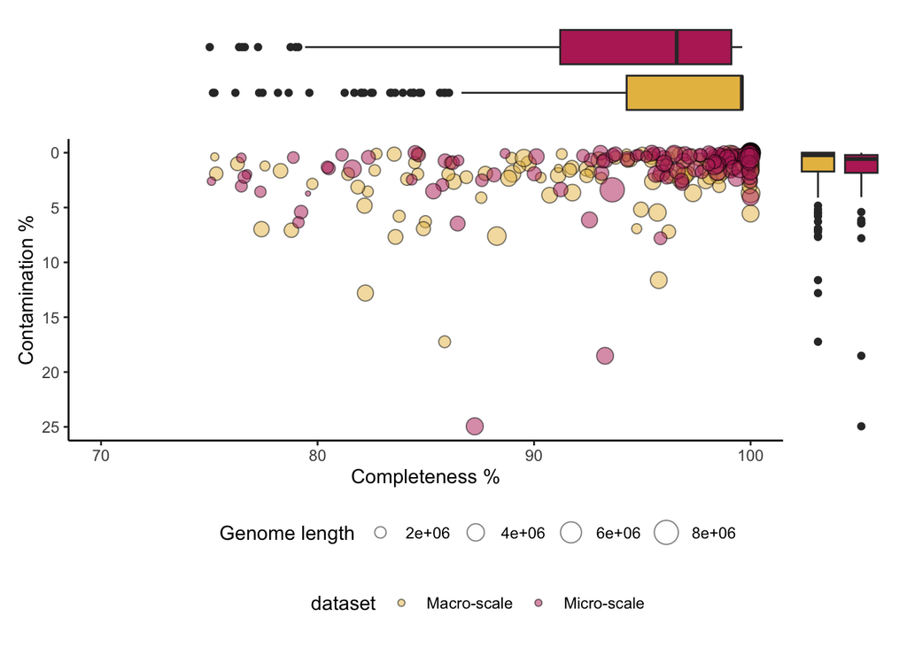

```r
# Load the genome metadata for macro- and micro- MAG catalogues
genome_biplot_data <- macromag_genomemetadata %>%
  select(genome,completeness, contamination, length) %>%
  mutate(dataset = "Macro-scale")

genome_biplot_micro_data <- micromag_genomemetadata %>%
  select(genome, completeness, contamination, length) %>%
  mutate(dataset = "Micro-scale")

# Combine the dfs
combined_data <- bind_rows(genome_biplot_data, genome_biplot_micro_data)

# Plot the combined data
combined_plot <- ggplot(combined_data, aes(x = completeness, y = contamination, size = length, fill = dataset)) +
  scale_fill_manual(values = c("#E8BD50", "#B92D65")) +
  geom_point(shape = 21, color = "black", alpha = 0.5) +
  xlim(c(70, 100)) +
  ylim(c(25, 0)) +
  labs(y = "Contamination %", x = "Completeness %", color = "MAG catalogue", size = "Genome length") +
  theme_classic() +
  theme(legend.position = "none")

# Plot contamination boxplot
genome_contamination <- combined_data %>%
            ggplot(aes(y=contamination, x=dataset, fill=dataset)) +
                    ylim(c(25,0)) +
                    geom_boxplot() +
                    theme_void() +
                    scale_fill_manual(values = c("#E8BD50", "#B92D65")) +
                    guides(fill = "none") +
                    theme(
                        axis.title.x = element_blank(),
                        axis.title.y = element_blank(),
                        axis.text.y=element_blank(),
                        axis.ticks.y=element_blank(),
                        axis.text.x=element_blank(),
                        axis.ticks.x=element_blank(),
                        plot.margin = unit(c(0, 0, 0.40, 0),"inches"))

# Plot completeness boxplot
genome_completeness <- combined_data %>%
        ggplot(aes(x=completeness, y=dataset, fill = dataset)) +
                xlim(c(70,100)) +
                geom_boxplot() +
                theme_void() +
                scale_fill_manual(values = c("#E8BD50", "#B92D65")) +
                guides(fill = "none") +
                theme(
                    axis.title.x = element_blank(),
                    axis.title.y = element_blank(),
                    axis.text.y=element_blank(),
                    axis.ticks.y=element_blank(),
                    axis.text.x=element_blank(),
                    axis.ticks.x=element_blank(),
                    plot.margin = unit(c(0, 0, 0, 0.50),"inches"))

# Align margins
genome_biplot <- combined_plot + theme(plot.margin = margin(5, 5, 5, 5))
genome_completeness <- genome_completeness + theme(plot.margin = margin(0, 5, 0, 5))
genome_contamination <- genome_contamination + theme(plot.margin = margin(5, 0, 5, 0))

# Compose layout
top_row <- genome_completeness + plot_spacer() + plot_layout(widths = c(15, 2))
bottom_row <- genome_biplot + genome_contamination + plot_layout(widths = c(15, 2))
fig2a <- (top_row / bottom_row + plot_layout(heights = c(5, 15))) + plot_layout(guides = "collect") &
  theme(legend.position = "bottom", legend.box = "vertical")

fig2a
```

### 3.1.3 Macro MAGs Overview (Fig. 2b)

```r
fig2b <- MAG_tree_plot(genome_metadata = macromag_genomemetadata, tree = macromag_tree)
```

```
*                          Note:                              *
*    force.ultrametric does not include a formal method to    *
*    ultrametricize a tree & should only be used to coerce    *
*   a phylogeny that fails is.ultrametric due to rounding --  *
*    not as a substitute for formal rate-smoothing methods.   *
```

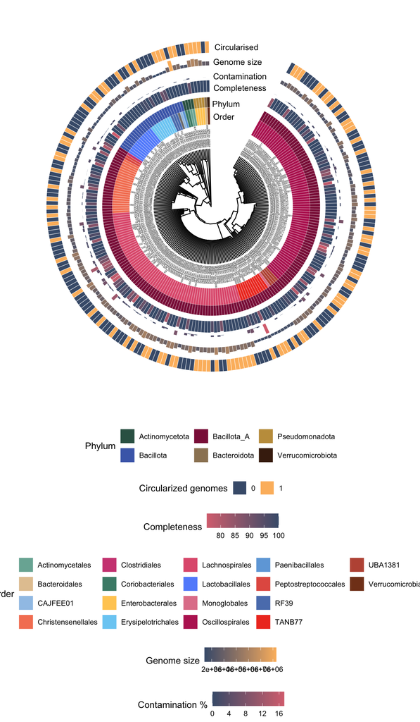

```r
fig2b
```

### 3.1.4 Micro MAGs Overview (Suppl. Fig. 1)

```r
figs1 <- MAG_tree_plot(genome_metadata = micromag_genomemetadata, tree = micromag_tree)
```

```
*                          Note:                              *
*    force.ultrametric does not include a formal method to    *
*    ultrametricize a tree & should only be used to coerce    *
*   a phylogeny that fails is.ultrametric due to rounding --  *
*    not as a substitute for formal rate-smoothing methods.   *
```

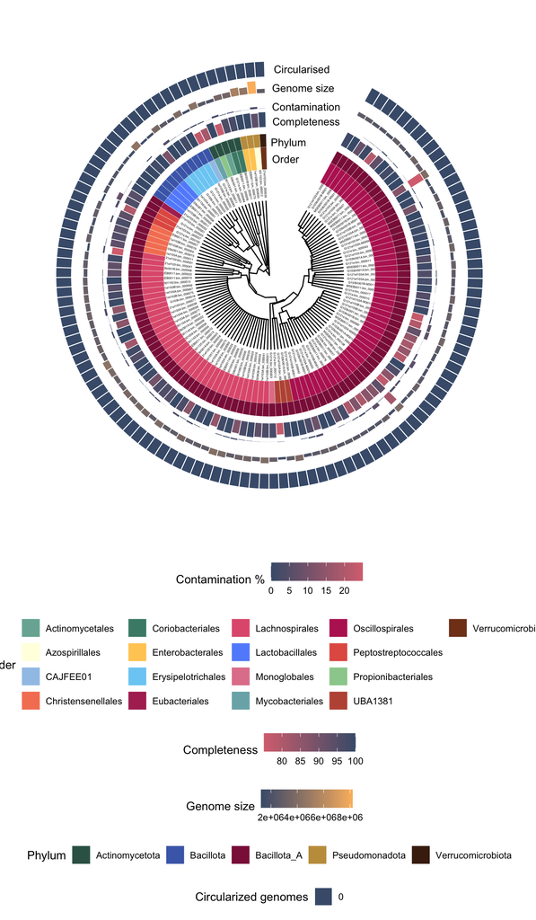

```r
figs1
```

### 3.1.5 Comparative Analysis Of Genome Catalogues (Suppl. Note 1)

```r
cat("Number Genomes in Macro-scale MAGs Catalogue =", length(macromag_taxonomy$genome), "\n")
```

```
Number Genomes in Macro-scale MAGs Catalogue = 223
```

```r
cat("Number Genomes in Micro-scale MAGs Catalogue =", length(micromag_taxonomy$genome), "\n")
```

```
Number Genomes in Micro-scale MAGs Catalogue = 122
```

```r
sn1_sample_id <- microquant_metrics_filt_30 %>% # select microquant dataset
  filter(
    batch %in% c("MSEB0011"),
    type %in% c("positive")
  ) %>% pull(microsample)

sn1_phylo_count <- full_join(
  microquant_genome_counts_filt_30 %>%
    select(genome, all_of(sn1_sample_id)) %>%
    rename_with(~ paste0(.x, "_micro"), .cols = -genome),
  macroquant_genome_counts_filt_30 %>%
    select(genome, all_of(sn1_sample_id)) %>%
    rename_with(~ paste0(.x, "_macro"), .cols = -genome),
  by = "genome"
) %>%
  mutate(across(
    where(is.numeric),
    ~ replace_na(.x, 0)
  )) %>%
  filter(if_any(where(is.numeric), ~ . != 0)) %>%
  select(
    genome,
    where(~ !is.numeric(.x) || sum(.x, na.rm = TRUE) != 0)
  ) %>%
  column_to_rownames("genome")

sn1_phylo_metadata <- bind_rows(
  microquant_metrics_filt_30 %>%
    mutate(
      sample_id = microsample,
      microsample = paste0(microsample, "_micro"),
      dataset = "Micro-scale"
    ),
  macroquant_metrics_filt_30 %>%
    mutate(
      sample_id = microsample,
      microsample = paste0(microsample, "_macro"),
      dataset = "Macro-scale"
    )
) %>%
  filter(microsample %in% c(names(sn1_phylo_count))) %>%
  column_to_rownames("microsample")

sn1_phylo_taxonomy <- bind_rows(micromag_taxonomy, macromag_taxonomy) %>%
  filter(genome %in% c(rownames(sn1_phylo_count))) %>%
  column_to_rownames("genome")

sn1_physeq <- phyloseq(
  sn1_phylo_count %>% otu_table(., taxa_are_rows = TRUE),
  sn1_phylo_metadata %>% sample_data(),
  sn1_phylo_taxonomy %>% as.matrix() %>% tax_table()
)

sn1_physeq_species <- tax_glom(sn1_physeq, taxrank = "species")
if (nrow(data.frame(sn1_physeq_species@tax_table) %>%
  rownames_to_column("genome") %>%
  count(species) %>%
  filter(n > 1)) > 0) {
  cat("warning: Some species appear more than once in the taxonomy table")
} else {
  cat("Verification: The combined macro and micro dataset contains only unique species.")
}
```

```
Verification: The combined macro and micro dataset contains only unique species.
```

```r
sn1_physeq_G121e <- subset_samples(sn1_physeq_species, animal == "G121e")
sn1_physeq_G121e <- prune_taxa(taxa_sums(sn1_physeq_G121e) > 0, sn1_physeq_G121e)
```

#### 3.1.5.1 Read Counts

```r
sn1_read_df <- bind_rows(
  lapply(list(
    micro = microquant_read_counts_filt_30 %>%
      select(genome, all_of(sn1_sample_id)),
    macro = macroquant_read_counts_filt_30 %>%
      select(genome, all_of(sn1_sample_id))
  ), function(df) {
    df %>%
      summarise(across(-1, sum)) %>%
      pivot_longer(cols = everything(), names_to = "microsample", values_to = "number_reads")
  }),
  .id = "source"
) %>% pivot_wider(names_from = source, values_from = number_reads)

sn1_cor_result <- cor.test(sn1_read_df$micro, sn1_read_df$macro, method = "spearman")
rho <- sn1_cor_result$estimate
pval <- sn1_cor_result$p.value
n <- length(sn1_read_df$micro)
# cat(sprintf("Correlation Spearman's ρ = %.2f, p = %.3f, n = %d", rho, pval, n), "\n")

sn1_read_count <- sn1_read_df %>%
  ggplot(aes(x = macro, y = micro)) +
  geom_point() +
  geom_abline(slope = 1, intercept = 0, linetype = "dashed") +
  stat_cor(
    method = "spearman", label.x = Inf, label.y = -Inf,
    hjust = 1.1, vjust = -1.1, size = 4
  ) + # adds the correlation
  custom_ggplot_theme +
  labs(
    x = "Mapped Reads \nMacro-scale Catalogue",
    y = "Mapped Reads \nMicro-scale Catalogue"
  )

print_median_iqr(sn1_read_df$macro / 1000000, "Macro-scale genome catalogue: ")
```

```
Macro-scale genome catalogue:  median = 10.58 IQR = 7.72 - 14.21
```

```r
print_median_iqr(sn1_read_df$micro / 1000000, "Micro-scale genome catalogue: ")
```

```
Micro-scale genome catalogue:  median = 11.8 IQR = 8.54 - 16
```

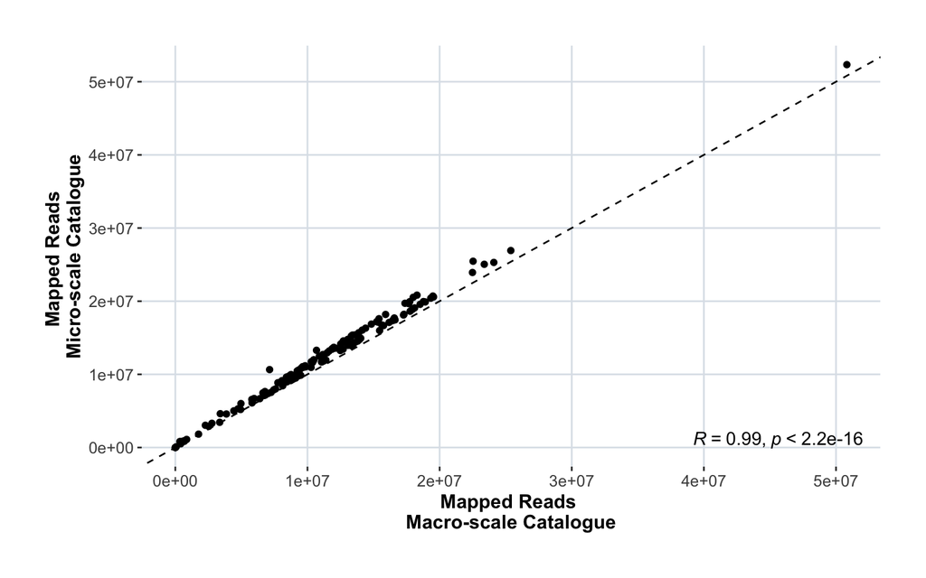

```r
sn1_read_count
```

Read mapping results were strongly correlated across the two catalogues.

#### 3.1.5.2 Alpha Diversity (Fig. S1.1a)

```r
sn1_alpha_df <- sample_data(sn1_physeq_species) %>%
  data.frame() %>%
  filter(richness > 0) %>%
  select(dataset, sample_id, richness, neutral, phylogenetic) %>%
  rename(`MAGs Catalogue` = dataset, microsample = sample_id)

sn1_alpha_df_wd <- sn1_alpha_df %>%
  pivot_wider(
    names_from = `MAGs Catalogue`,
    names_glue = "{`MAGs Catalogue`}_{.value}",
    values_from = c(richness, neutral, phylogenetic)
  )
sn1_alpha_df_lg <- sn1_alpha_df %>%
  pivot_longer(
    cols = c(richness, neutral, phylogenetic),
    names_to = "metric",
    values_to = "value"
  ) %>%
  mutate(metric = factor(metric,
    levels = c("richness", "neutral", "phylogenetic")
  ))
```

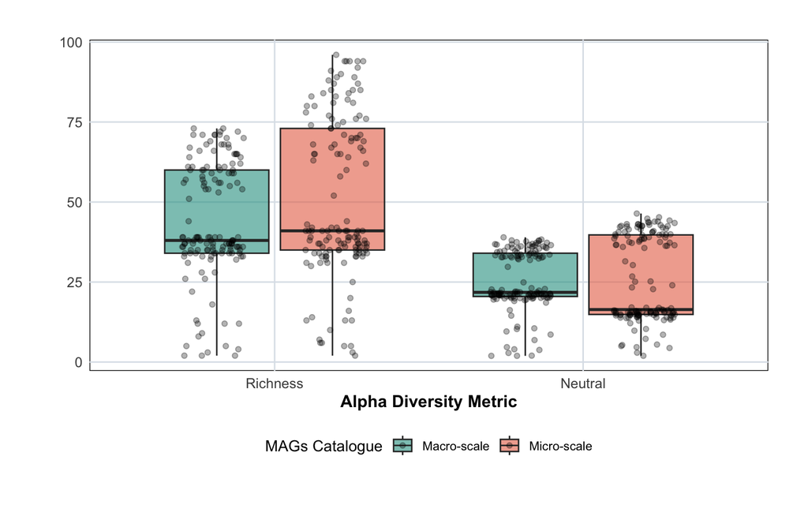

```r
figs1_1a <- sn1_alpha_df_lg %>%
  filter(
    !metric %in% c("phylogenetic"),
    (metric == "neutral" & value > 1) |
      (metric == "richness" & value > 0)
  ) %>%
  mutate(metric = fct_recode(metric,
    "Richness" = "richness",
    "Neutral" = "neutral"
  )) %>%
  ggplot(aes(x = metric, y = value, fill = `MAGs Catalogue`)) +
  geom_boxplot(alpha = 0.6) +
  geom_jitter(
    position = position_jitterdodge(jitter.width = 0.2, dodge.width = 0.8),
    size = 1.5, alpha = 0.3
  ) +
  theme_minimal() +
  scale_fill_manual(values = c("#2A9D8F", "#E76F51")) +
  custom_ggplot_theme +
  labs(
    # title = "a",
    x = "Alpha Diversity Metric",
    y = ""
  ) +
  theme(legend.position = "bottom")
figs1_1a
```

##### Richness

```r
# 5 nas?
wt <- wilcox.test(
  sn1_alpha_df_wd$`Micro-scale_richness`,
  sn1_alpha_df_wd$`Macro-scale_richness`,
  paired = TRUE,
  na.action = na.omit
) %>% broom::tidy()
wt$p.value <- formatC(wt$p.value, format = "e", digits = 3)
knitr::kable(wt, digits = 3)
```

| statistic | p.value | method | alternative |
| --- | --- | --- | --- |
| 7486.5 | 1.590e-20 | Wilcoxon signed rank test with continuity correction | two.sided |

##### Neutral

```r
# 5 nas?
knitr::kable(
  wilcox.test(
    sn1_alpha_df_wd$`Micro-scale_neutral`,
    sn1_alpha_df_wd$`Macro-scale_neutral`,
    paired = TRUE, na.action = na.omit
  ) %>% broom::tidy(),
  digits = 3
)
```

| statistic | p.value | method | alternative |
| --- | --- | --- | --- |
| 5078 | 0.882 | Wilcoxon signed rank test with continuity correction | two.sided |

#### 3.1.5.3 Detected Taxa

```r
microscale_taxa <- left_join(
  microquant_genome_counts_filt_30 %>%
    select(genome, all_of(sn1_sample_id)) %>%
    filter(rowSums(across(where(is.numeric))) > 0) %>% select(genome) %>% as.data.frame(),
  micromag_taxonomy,
  by = "genome"
)
macroscale_taxa <- left_join(
  macroquant_genome_counts_filt_30 %>%
    select(genome, all_of(sn1_sample_id)) %>%
    filter(rowSums(across(where(is.numeric))) > 0) %>% select(genome) %>% as.data.frame(),
  macromag_taxonomy,
  by = "genome"
)
```

##### Number Unique Species

```r
micro_unique_species <- setdiff(microscale_taxa$species, macroscale_taxa$species)
macro_unique_species <- setdiff(macroscale_taxa$species, microscale_taxa$species)
sn1_unique_species_df <- tibble(
  species = c(micro_unique_species, macro_unique_species),
  source = c(
    rep("Micro-scale", length(micro_unique_species)),
    rep("Macro-scale", length(macro_unique_species))
  )
)
cat("Micro-scale MAGs Catalogue =", length(micro_unique_species), "\n")
```

```
Micro-scale MAGs Catalogue = 40
```

```r
cat("Macro-scale MAGs Catalogue =", length(macro_unique_species), "\n")
```

```
Macro-scale MAGs Catalogue = 8
```

##### Number Unique Genera

```r
micro_unique_genera <- setdiff(microscale_taxa$genus, macroscale_taxa$genus)
macro_unique_genera <- setdiff(macroscale_taxa$genus, microscale_taxa$genus)
sn1_unique_genera_df <- tibble(
  genera = c(micro_unique_genera, macro_unique_genera),
  source = c(
    rep("Micro-scale", length(micro_unique_genera)),
    rep("Macro-scale", length(macro_unique_genera))
  )
)
cat("Micro-scale MAGs Catalogue =", length(micro_unique_genera), "\n")
```

```
Micro-scale MAGs Catalogue = 28
```

```r
cat("Macro-scale MAGs Catalogue =", length(macro_unique_genera), "\n")
```

```
Macro-scale MAGs Catalogue = 0
```

A greater number of unique taxa were detected with the microscale.

#### 3.1.5.4 Beta Diversity (Fig. S1.1b)

```r
sn1_betacount_df <- data.frame(otu_table(sn1_physeq_species)) %>%
  rownames_to_column("genome") %>%
  melt(id = "genome") %>%
  setNames(c("genome", "microsample", "count")) %>%
  left_join(data.frame(tax_table(sn1_physeq_species)) %>%
    rownames_to_column("genome"), by = "genome") %>%
  select(species, microsample, count) %>%
  filter(count > 0) %>%
  pivot_wider(names_from = species, values_from = count, values_fill = 0) %>% # change here
  select(where(~ any(. != 0))) %>%
  mutate(across(-microsample, ~ . / rowSums(across(where(is.numeric))) * 100)) %>%
  column_to_rownames(var = "microsample")
```

##### Centered Log-Ratio (CLR) Transformation And Principal Component Analysis (PCA)

**Note:** The perform_pca() function needs to be loaded.

```r
# cat("Zero replacement determined", "\n")
sn1_beta_obj <- perform_pca(sn1_betacount_df)
```

```
[1] "Zeros found"
```

```
No. adjusted imputations:  1410
Rows (samples) removed after zero replacement: 26
Columns (taxa) removed after zero replacement: 47
```

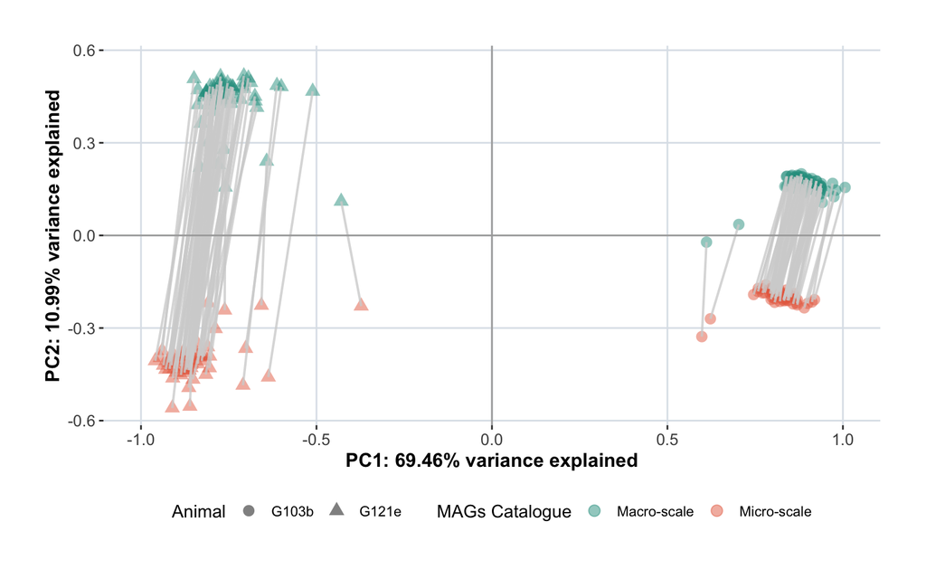

```r
sn1_beta_metadata <- data.frame(sample_data(sn1_physeq_species)) %>%
  rownames_to_column("microsample") %>%
  filter(microsample %in% c(rownames(sn1_beta_obj$df_clr))) %>%
  rename(
    `MAGs Catalogue` = dataset,
    Animal = animal
  )

sn1_scores <- rownames_to_column(as.data.frame(sn1_beta_obj$pca_result$x), var = "microsample")
sn1_scores <- left_join(sn1_scores, sn1_beta_metadata, by = join_by(microsample == microsample))
variance_explained <- (sn1_beta_obj$pca_result$sdev^2) / sum(sn1_beta_obj$pca_result$sdev^2) * 100
figs1_1b <- ggplot() +
  geom_point(
    data = sn1_scores,
    aes(x = PC1, y = PC2, group = microsample, color = `MAGs Catalogue`, shape = Animal),
    size = 3, alpha = 0.5
  ) +
  scale_color_manual(values = c("#2A9D8F", "#E76F51")) +
  geom_path(
    data = sn1_scores,
    aes(x = PC1, y = PC2, group = sample_id),
    linewidth = 0.7, alpha = 0.8, color = "lightgrey"
  ) +
  labs(
    # title = "b",
    x = paste0("PC1: ", round(variance_explained[1], 2), "% variance explained"),
    y = paste0("PC2: ", round(variance_explained[2], 2), "% variance explained")
  ) +
  scale_x_continuous(limits = c(-max(abs(sn1_scores$PC1)), max(abs(sn1_scores$PC1)))) + # Calculate symmetric limits based on data
  scale_y_continuous(limits = c(-max(abs(sn1_scores$PC2)), max(abs(sn1_scores$PC2)))) + # Calculate symmetric limits based on data
  geom_hline(yintercept = 0, color = "darkgrey") + # Horizontal line at y = 0
  geom_vline(xintercept = 0, color = "darkgrey") + # Vertical line at x = 0
  custom_ggplot_theme +
  theme(legend.position = "bottom")
figs1_1b
```

The 35-day-old animal (G121e) showed the greatest species-level differences between catalogues.

##### Differential Abundance (Aldex2)

```r
structural_zero <- data.frame(otu_table(tax_glom(sn1_physeq_G121e, taxrank = "species"))) %>%
  rownames_to_column("genome") %>%
  pivot_longer(cols = -c(genome), names_to = "microsample", values_to = "abundance") %>%
  mutate(dataset = str_sub(microsample, -5, -1)) %>%
  group_by(dataset, genome) %>%
  summarise(sum_abundance = sum(abundance)) %>%
  filter(sum_abundance == 0) %>%
  pull(genome)

sn1_aldex_G121e_counts <- data.frame(otu_table(tax_glom(sn1_physeq_G121e, "species"))) # %>%
# rownames_to_column("genome") %>%
# filter(!genome %in%c(structural_zero)) %>%
# column_to_rownames("genome")
sn1_aldex_G121e_pseudo_counts <- round(sn1_aldex_G121e_counts * 1e6)
sn1_aldex_G121e_conditions <- data.frame(sample_data(tax_glom(sn1_physeq_G121e, "species"))) %>% pull(dataset)
sn1_aldex_G121e_results <- aldex(sn1_aldex_G121e_pseudo_counts,
  sn1_aldex_G121e_conditions,
  test = "t",
  effect = TRUE, # include effect sizes
  denom = "all", # normalization denominator
  mc.samples = 256, # number of Monte Carlo instances
  verbose = TRUE
)
```

```
|------------(25%)----------(50%)----------(75%)----------|
```

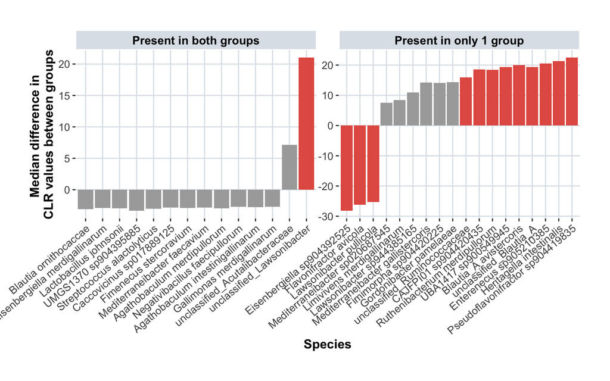

```r
# - we.ep: expected p-value from Welch's t-test
# - wi.ep: expected p-value from Wilcoxon test
# - we.eBH: BH-adjusted p-value (q-value)
# - effect: effect size (difference in clr means / variability)
# Filter
sn1_aldex_G121e_sig <- sn1_aldex_G121e_results[sn1_aldex_G121e_results$we.eBH < 0.05, ]
sn1_aldex_G121e_effect <- sn1_aldex_G121e_sig[abs(sn1_aldex_G121e_sig$effect) > 0.5, ]
sn1_aldex <-
  sn1_aldex_G121e_effect %>%
  rownames_to_column("genome") %>%
  left_join(data.frame(tax_table(tax_glom(sn1_physeq_G121e, "species"))) %>% rownames_to_column("genome"), by = "genome")

figs1_1c <- sn1_aldex %>%
  mutate(structural_zero = ifelse(genome %in% c(structural_zero), "Present in only 1 group", "Present in both groups")) %>%
  ggplot(., aes(x = diff.btw, y = reorder(species, effect), fill = abs(effect) > 1)) +
  geom_bar(stat = "identity", show.legend = FALSE) +
  coord_flip() +
  labs(
    x = "Median difference in \nCLR values between groups",
    y = "Species"
  ) +
  scale_fill_manual(values = c("TRUE" = "#e35d51", "FALSE" = "darkgrey")) +
  custom_ggplot_theme +
  facet_wrap(~structural_zero, scale = "free") +
  theme(axis.text.x = element_text(angle = 40, hjust = 1))
figs1_1c
```

Differentially abundant species in the 35-day-old animal (G121e) are primarily structural 0.

## 3.2 Collection attempts vs. success (Suppl.Fig. 4)

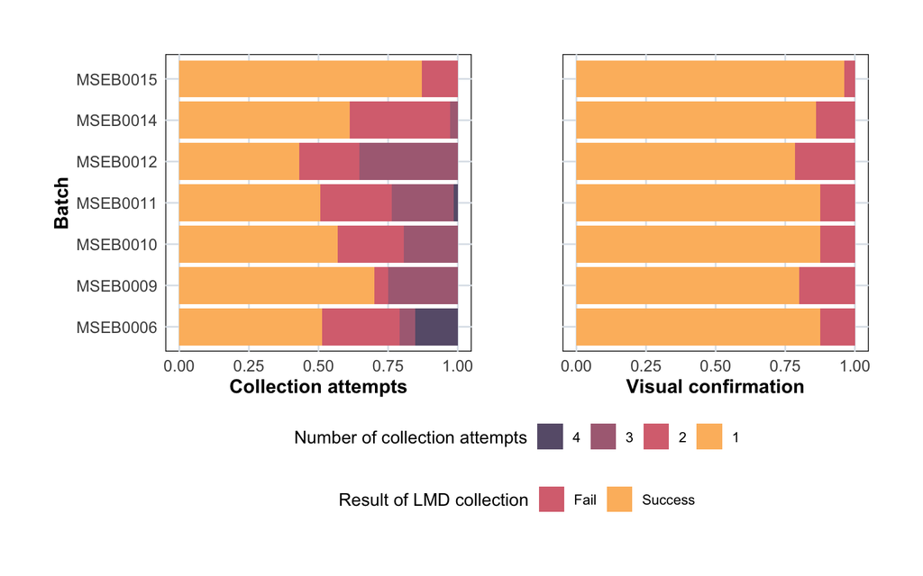

```r
collection_success_df <- macroquant_metrics_filt_30 %>%
  filter(batch == "MSEB0006" |
          batch == "MSEB0009" |
          batch == "MSEB0010" |
          batch == "MSEB0011" |
          batch == "MSEB0012" |
          batch == "MSEB0014" |
          batch == "MSEB0015") %>%
  filter(type == "positive") %>%
  filter(collection_attempts > 0)

 collection_attempts_plot <- collection_success_df %>%
  mutate(collection_attempts = factor(collection_attempts, levels = c(4, 3, 2, 1))) %>%
  ggplot(aes(y = batch,  fill = collection_attempts)) +
  geom_bar(position = "fill") +
  scale_fill_manual(values = c("#685d79","#ac6d83","#d9727f","#fcbb6d")) +
  theme_minimal() +
  custom_ggplot_theme +
  labs(x = "Collection attempts",y = "Batch" ,fill = "Number of collection attempts") +
  theme(legend.position = "bottom")

collection_success_plot <- collection_success_df %>%
  mutate(collection = factor(collection, levels = c("Fail", "Success"))) %>%
  ggplot(aes(y = batch,  fill = collection)) +
  geom_bar(position = "fill") +
  scale_fill_manual(values = c("#d9727f", "#fcbb6d")) +
  theme_minimal() +
  custom_ggplot_theme +
  labs(x = "Visual confirmation" ,y =  "Batch",fill = "Result of LMD collection") +
  theme(legend.position = "bottom")

figs4 <- collection_attempts_plot + collection_success_plot +
  plot_layout(axes = "collect", guides = "collect") &
  theme(legend.position = "bottom", legend.box = "vertical")
figs4
```

### 3.2.1 Collection success at different microsample areas

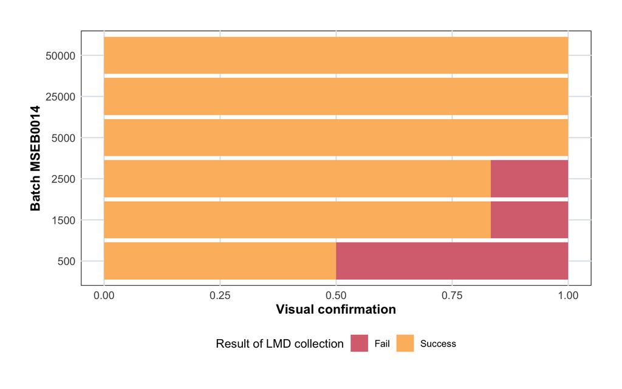

```r
collection_success_plot_size <- collection_success_df %>%
  mutate(size = factor(size, levels = c(500, 1500, 2500, 5000, 25000, 50000))) %>%
  filter(batch == "MSEB0014") %>%
  mutate(collection = factor(collection, levels = c("Fail", "Success"))) %>%
  ggplot(aes(y = size,  fill = collection)) +
  geom_bar(position = "fill") +
  scale_fill_manual(values = c("#d9727f", "#fcbb6d")) +
  theme_minimal() +
  custom_ggplot_theme +
  labs(x = "Visual confirmation" ,y =  "Batch MSEB0014",fill = "Result of LMD collection") +
  theme(legend.position = "bottom")
collection_success_plot_size
```

```r
collection_success_df %>%
  select(microsample, collection_attempts) %>%
  count(collection_attempts) %>%
  mutate(percent = 100 * n / sum(n)) %>%
  knitr::kable(align = "lccc")
```

| collection_attempts | n | percent |
| --- | --- | --- |
| 1 | 332 | 55.518395 |
| 2 | 140 | 23.411371 |
| 3 | 113 | 18.896321 |
| 4 | 13 | 2.173913 |

## 3.3 Tissue Lysis And Sequencing Library Preparation (Suppl. Note 3)

### 3.3.1 Impact of Lysis Conditions On Microbial Taxonomic Profiling (Suppl. Note 3.2)

#### 3.3.1.1 Mock Community (Fig. S3.2.1)

```r
# Select samples & close composition
mock_wide <- tidy_plot_genome_counts_filt_30_mock_closed %>%
  filter(culture == "MX") %>%
  select(genome, microsample, count) %>%
  pivot_wider(names_from = genome,values_from = count,values_fill = 0) %>%
  select(where(~ any(. != 0)) | where(is.character) | where(is.factor)) %>%
  column_to_rownames(var = "microsample") %>%
  mutate(across(where(is.numeric), ~ . / rowSums(across(where(is.numeric))) * 100))

# Transform genome counts to CLR relative abundance values
mock_wide_CLR <- as.data.frame(t(apply(mock_wide, 1, clr_transform)))

# Pivot df to tidy for plotting
mock_wide_CLR_tidy <- mock_wide_CLR %>%
  # Convert row names into a column
  rownames_to_column(var = "microsample") %>%
  # Convert all other columns (microbes) into long format
  pivot_longer(cols = -microsample,
               names_to = "genome",
               values_to = "relabun") %>%
  left_join(genome_metadata_mock, by = join_by(genome == genome)) %>%
  left_join(sample_metadata_mock, by = join_by(microsample == sample)) %>%
  select(-LabBatch_text, -culture) %>%
  # Set expected CLR value for all genomes
  mutate(expected = 0) %>% # not really needed, obviously, but for consistency
  mutate(error = relabun - expected)

mock_RMSE_df <- mock_wide_CLR_tidy %>%
  group_by(genome, buffer) %>%
  summarise(
    # Root Mean Squared Error across samples for each taxon for each buffer
    RMSE = sqrt(mean(error^2, na.rm = TRUE)),
    span = (max(relabun, na.rm = TRUE) - min(relabun, na.rm = TRUE)),
    .groups = "drop"
  )

mock_RMSE_df %>%
  group_by(buffer) %>%
  summarise(median_RMSE = median(RMSE, na.rm = TRUE)) %>%
  knitr::kable(align = "lccc")
```

| buffer | median_RMSE |
| --- | --- |
| L01 | 0.4968693 |
| L02 | 0.4064754 |
| L03 | 0.4724400 |
| L04 | 0.3642177 |
| L05 | 0.3894757 |
| L06 | 0.2090295 |
| L07 | 0.2146873 |
| L08 | 0.5200282 |

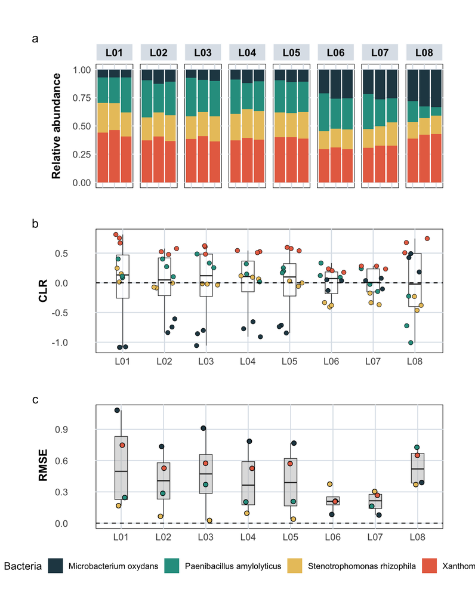

```r
custom_ggplot_theme_mock <- custom_ggplot_theme +
  theme(plot.margin = unit(c(0, 0, 0, 0), "pt"))

# Composition of the mock community plot
figs3_2_1_a <- tidy_plot_genome_counts_filt_30_mock_closed %>%
  filter(culture == "MX") %>%
  ggplot(aes(x = microsample, y = count, fill = species, group = species)) +
  geom_col(position = "fill") +
  scale_fill_manual(values = c("#264653", "#2A9D8F", "#E9C46A", "#E76F51")) +
  labs(x = NULL, y = "Relative abundance", fill = "Bacteria") +
  facet_nested(. ~ buffer, scales = "free", space = "free", switch = "y") +
  theme_minimal() +
  custom_ggplot_theme +
  theme(axis.text.x = element_blank()) +
  theme(legend.position = "bottom") +
  theme(panel.spacing = unit(0.5, "lines"))

# CLR values (relative abundance) of each taxon vs expected relative abundance (CLR=0)
figs3_2_1_b <- mock_wide_CLR_tidy %>%
  ggplot(aes(x = buffer, y = relabun)) +
  geom_boxplot(
    width = 0.3, alpha = 0.5, size = 0.3,
    outlier.shape = NA, position = position_dodge(width = 0.9)
  ) +
  geom_jitter(aes(fill = genome, group = buffer),
    size = 2, alpha = 1.0, shape = 21,
    color = "black",
    stroke = 0.3,
    position = position_jitterdodge(jitter.width = 0.6, dodge.width = 0.9)
  ) +
  scale_fill_manual(values = c("#264653", "#2A9D8F", "#E9C46A", "#E76F51")) +
  labs(x = NULL, y = "CLR") +
  geom_hline(yintercept = 0, linetype = "dashed", color = "black", label = "expected error", linewidth = 0.5) +
  theme_minimal() +
  custom_ggplot_theme_mock +
  theme(legend.position = "none") +
  guides(fill = "none")

# RMSE of CLR relative abundance vs expected CLR
figs3_2_1_c <- ggplot(mock_RMSE_df, aes(x = buffer, y = RMSE)) + # y = mean_RMSE
  geom_boxplot(
    width = 0.3, size = 0.3,
    outlier.shape = NA, fill = "grey", alpha = 0.5
  ) +
  geom_jitter(aes(fill = genome),
    size = 2,
    shape = 21,
    color = "black",
    stroke = 0.5,
    width = 0.1, alpha = 1.0
  ) +
  scale_fill_manual(values = c("#264653", "#2A9D8F", "#E9C46A", "#E76F51")) +
  labs(x = NULL, y = " RMSE") +
  # scale_y_continuous(
  #   limits = c(-0, 10),
  #   breaks = seq(0, 10, by = 0.1)) +
  geom_hline(yintercept = 0, linetype = "dashed", color = "black", label = "expected error", linewidth = 0.5) +
  theme_minimal() +
  custom_ggplot_theme +
  theme(legend.position = "none") +
  guides(fill = "none")

# Combined plot
figs3_2_1 <- figs3_2_1_a / figs3_2_1_b / figs3_2_1_c +
  plot_annotation(tag_levels = 'a') +
  plot_layout(guides = "collect") &
  theme(legend.position = "bottom", legend.box = "vertical")

figs3_2_1
```

#### 3.3.1.2 Microsamples (Fig. S3.2.2)

```r
sn3_2_df <- macroquant_metrics_filt_30 %>%
  filter(
    batch %in% c("MSEB0006", "MSEB0010"), # Caeucum (MSEB0006) and Colon (MSEB0010)
    section %in% c("Caecum right", "Colon"),
    cycles %in% c(13, 14, 15),
    type %in% c("positive"),
    richness > 0
  ) %>%
  mutate(
    collection_attempts = as.factor(collection_attempts),
    buffer = as.factor(buffer)
  )
```

##### 3.3.1.2.1 Visual Comparison Of Sequencing Performance (Fig. S3.2.2)

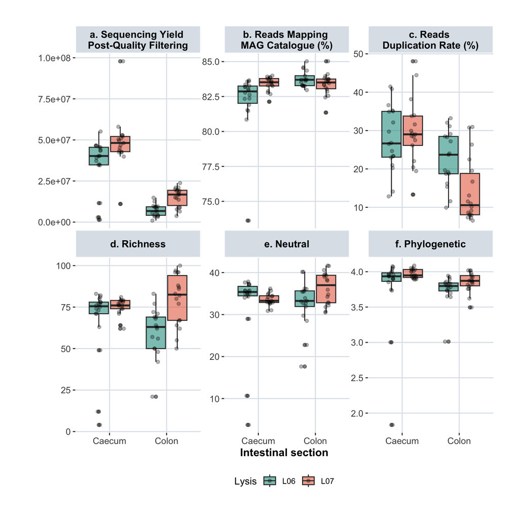

```r
ordered_metrics <- c(
  "total_after_filtering.total_reads",
  "mapmag_prokreads_pct",
  "percent_duplication.rate",
  "richness",
  "neutral",
  "phylogenetic"
)

figs3_2_2 <- sn3_2_df %>%
  mutate(
    mapmag_prokreads_pct = mapmag_prokreads_pct * 100,
    percent_duplication.rate = percent_duplication.rate * 100
  ) %>%
  pivot_longer(
    cols = -c(names(mssm_sample_metadata), "cov_filtering"),
    names_to = "metric",
    values_to = "value"
  ) %>%
  filter(metric %in% ordered_metrics) %>%
  mutate(
    metric = factor(metric, levels = ordered_metrics),
    metric = fct_recode(metric,
      "a. Sequencing Yield \nPost-Quality Filtering" = "total_after_filtering.total_reads",
      "b. Reads Mapping \nMAG Catalogue (%)" = "mapmag_prokreads_pct",
      "c. Reads \nDuplication Rate (%)" = "percent_duplication.rate",
      "d. Richness" = "richness",
      "e. Neutral" = "neutral",
      "f. Phylogenetic" = "phylogenetic"
    ),
    section = recode(section,
      "Caecum right" = "Caecum",
      "Colon" = "Colon"
    )
  ) %>%
  ggplot(aes(x = section, y = value, fill = buffer)) +
  geom_boxplot(alpha = 0.6) +
  facet_wrap(~metric, scales = "free_y", ncol = 3) +
  labs(
    fill = "Lysis",
    y = "",
    x = "Intestinal section"
  ) +
  # geom_violin(trim = TRUE, alpha = 0.7, position = position_dodge(0.8), na.rm = TRUE) +  # Violin plot
  geom_jitter(
    position = position_jitterdodge(jitter.width = 0.2, dodge.width = 0.8),
    size = 1.5, alpha = 0.3
  ) +
  scale_fill_manual(values = c("#2A9D8F", "#E76F51")) +
  custom_ggplot_theme +
  theme(legend.position = "bottom")

figs3_2_2
```

No clear performance advantage was observed between methods L06 and L07 in caecum microsamples. Although L06 was initially selected, a subsequent experiment suggested that L07 may offer enhanced lysis performance in colon microsamples.

##### 3.3.1.2.2 Statistical Comparison Of Sequencing Performance

**Note:** The fit_and_analyze_model() function needs to be loaded.

###### a. Reads Retained Post Quality Filtering

###### Caecum

```r
# Counts (integers ≥0): poisson, quasipoisson (accounts overdispersion)
sn3_2_a_ca <- fit_and_analyze_model(
  model = "glm",
  distribution = "quasipoisson",
  response_var = "total_after_filtering.total_reads",
  explanatory_var = "collection_attempts + buffer",
  data = sn3_2_df %>% filter(section %in% c("Caecum right"))
)
knitr::kable(
  sn3_2_a_ca$anova,
  digits = 3,
  booktabs = TRUE,
  align = "lccc"
)
```

| term | sumsq | df | statistic | p.value |
| --- | --- | --- | --- | --- |
| collection_attempts | 18686423 | 3 | 1.003 | 0.405 |
| buffer | 42250297 | 1 | 6.802 | 0.014 |
| Residuals | 186338647 | 30 | NA | NA |

###### Colon

```r
# Counts (integers ≥0): poisson, quasipoisson (accounts overdispersion)
sn3_2_a_co <- fit_and_analyze_model(
  model = "glm",
  distribution = "quasipoisson",
  response_var = "total_after_filtering.total_reads",
  explanatory_var = "collection_attempts + buffer",
  data = sn3_2_df %>% filter(section %in% c("Colon"))
)
knitr::kable(
  sn3_2_a_co$anova,
  digits = 3,
  booktabs = TRUE,
  align = "lccc"
)
```

| term | sumsq | df | statistic | p.value |
| --- | --- | --- | --- | --- |
| collection_attempts | 6870290 | 2 | 1.732 | 0.194 |
| buffer | 46063248 | 1 | 23.230 | 0.000 |
| Residuals | 61470462 | 31 | NA | NA |

###### b. Reads Mapping MAG Catalogue (%)

###### Caecum

```r
# Proportions (0–1 continuous): quasibinomial GLM (accounts overdispersion)
sn3_2_b_ca <- fit_and_analyze_model(
  model = "glm",
  distribution = "quasibinomial",
  response_var = "mapmag_prokreads_pct",
  explanatory_var = "collection_attempts + buffer",
  data = sn3_2_df %>% filter(section %in% c("Caecum right"))
)

knitr::kable(
  sn3_2_b_ca$anova,
  digits = 3,
  booktabs = TRUE,
  align = "lccc"
)
```

| term | sumsq | df | statistic | p.value |
| --- | --- | --- | --- | --- |
| collection_attempts | 0.002 | 3 | 0.382 | 0.767 |
| buffer | 0.010 | 1 | 4.837 | 0.036 |
| Residuals | 0.061 | 30 | NA | NA |

###### Colon

```r
# Proportions (0–1 continuous): quasibinomial GLM (accounts overdispersion)
sn3_2_b_co <- fit_and_analyze_model(
  model = "glm",
  distribution = "quasibinomial",
  response_var = "mapmag_prokreads_pct",
  explanatory_var = "collection_attempts + buffer",
  data = sn3_2_df %>% filter(section %in% c("Colon"))
)

knitr::kable(
  sn3_2_b_co$anova,
  digits = 3,
  booktabs = TRUE,
  align = "lccc"
)
```

| term | sumsq | df | statistic | p.value |
| --- | --- | --- | --- | --- |
| collection_attempts | 0.001 | 2 | 1.854 | 0.174 |
| buffer | 0.001 | 1 | 3.882 | 0.058 |
| Residuals | 0.010 | 31 | NA | NA |

###### c. Reads Duplication Rate (%)

###### Caecum

```r
# Proportions (0–1 continuous): quasibinomial GLM (accounts overdispersion)
sn3_2_c_ca <- fit_and_analyze_model(
  model = "glm",
  distribution = "quasibinomial",
  response_var = "percent_duplication.rate",
  explanatory_var = "collection_attempts + buffer",
  data = sn3_2_df %>% filter(section %in% c("Caecum right"))
)

knitr::kable(
  sn3_2_c_ca$anova,
  digits = 3,
  booktabs = TRUE,
  align = "lccc"
)
```

| term | sumsq | df | statistic | p.value |
| --- | --- | --- | --- | --- |
| collection_attempts | 0.009 | 3 | 0.075 | 0.973 |
| buffer | 0.017 | 1 | 0.426 | 0.519 |
| Residuals | 1.174 | 30 | NA | NA |

###### Colon

```r
# Proportions (0–1 continuous): quasibinomial GLM (accounts overdispersion)
sn3_2_c_co <- fit_and_analyze_model(
  model = "glm",
  distribution = "quasibinomial",
  response_var = "percent_duplication.rate",
  explanatory_var = "collection_attempts + buffer",
  data = sn3_2_df %>% filter(section %in% c("Colon"))
)

knitr::kable(
  sn3_2_c_co$anova,
  digits = 3,
  booktabs = TRUE,
  align = "lccc"
)
```

| term | sumsq | df | statistic | p.value |
| --- | --- | --- | --- | --- |
| collection_attempts | 0.173 | 2 | 2.161 | 0.132 |
| buffer | 0.357 | 1 | 8.944 | 0.005 |
| Residuals | 1.238 | 31 | NA | NA |

```r
## cat("Predicted values from model", "\n")

knitr::kable(
  sn3_2_c_co$model_fit %>% ggpredict(., terms = c("buffer")),
  digits = 3,
  booktabs = TRUE,
  align = "lccc"
)
```

| x | predicted | std.error | conf.low | conf.high | group |
| --- | --- | --- | --- | --- | --- |
| L06 | 0.250 | 0.129 | 0.204 | 0.303 | 1 |
| L07 | 0.163 | 0.158 | 0.124 | 0.212 | 1 |

###### Caecum

```r
# Counts (integers ≥0): poisson, quasipoisson (accounts overdispersion)
sn3_2_d_ca <- fit_and_analyze_model(
  model = "glm",
  distribution = "quasipoisson",
  response_var = "richness",
  explanatory_var = "collection_attempts + buffer",
  data = sn3_2_df %>% filter(section %in% c("Caecum right"))
)
knitr::kable(
  sn3_2_d_ca$anova,
  digits = 3,
  booktabs = TRUE,
  align = "lccc"
)
```

| term | sumsq | df | statistic | p.value |
| --- | --- | --- | --- | --- |
| collection_attempts | 9.381 | 3 | 0.689 | 0.566 |
| buffer | 12.508 | 1 | 2.755 | 0.107 |
| Residuals | 136.200 | 30 | NA | NA |

###### Colon

```r
# Counts (integers ≥0): poisson, quasipoisson (accounts overdispersion)
sn3_2_d_co <- fit_and_analyze_model(
  model = "glm",
  distribution = "quasipoisson",
  response_var = "richness",
  explanatory_var = "collection_attempts + buffer",
  data = sn3_2_df %>% filter(section %in% c("Colon"))
)

knitr::kable(
  sn3_2_d_co$anova,
  digits = 3,
  booktabs = TRUE,
  align = "lccc"
)
```

| term | sumsq | df | statistic | p.value |
| --- | --- | --- | --- | --- |
| collection_attempts | 10.762 | 2 | 1.695 | 0.200 |
| buffer | 41.227 | 1 | 12.988 | 0.001 |
| Residuals | 98.402 | 31 | NA | NA |

###### Caecum

```r
sn3_2_e_ca <- fit_and_analyze_model(
  model = "lm",
  response_var = "neutral",
  explanatory_var = "collection_attempts + buffer",
  data = sn3_2_df %>% filter(section %in% c("Caecum right"))
)

knitr::kable(
  sn3_2_e_ca$anova,
  digits = 3,
  booktabs = TRUE,
  align = "lccc"
)
```

| term | sumsq | df | statistic | p.value |
| --- | --- | --- | --- | --- |
| collection_attempts | 129.032 | 3 | 0.912 | 0.447 |
| buffer | 40.969 | 1 | 0.869 | 0.359 |
| Residuals | 1414.783 | 30 | NA | NA |

###### Colon

```r
sn3_2_e_co <- fit_and_analyze_model(
  model = "lm",
  response_var = "neutral",
  explanatory_var = "collection_attempts + buffer",
  data = sn3_2_df %>% filter(section %in% c("Colon"))
)
# plot(sn3_2_e_co$simResidual)

knitr::kable(
  sn3_2_e_co$anova,
  digits = 3,
  booktabs = TRUE,
  align = "lccc"
)
```

| term | sumsq | df | statistic | p.value |
| --- | --- | --- | --- | --- |
| collection_attempts | 88.152 | 2 | 2.017 | 0.150 |
| buffer | 96.347 | 1 | 4.409 | 0.044 |
| Residuals | 677.483 | 31 | NA | NA |

```r
sn3_2_taxa <- left_join(
  macroquant_genome_counts_filt_30 %>%
    select(genome, all_of(sn3_2_df$microsample)) %>%
    filter(rowSums(across(where(is.numeric))) > 0) %>%
    melt(id = "genome", variable.name = "microsample"),
  macromag_taxonomy,
  by = "genome"
) %>%
  left_join(macroquant_metrics_filt_30, by = "microsample") %>%
  filter(
    value > 0,
    section %in% c("Colon")
  )

sn3_2_unique_L06 <- setdiff(
  sn3_2_taxa %>% filter(buffer %in% c("L06")) %>% distinct(genus),
  sn3_2_taxa %>% filter(buffer %in% c("L07")) %>% distinct(genus)
)
sn3_2_unique_L07 <- setdiff(
  sn3_2_taxa %>% filter(buffer %in% c("L07")) %>% distinct(genus),
  sn3_2_taxa %>% filter(buffer %in% c("L06")) %>% distinct(genus)
)

sn3_2_unique_genus_df <- tibble(
  genus = c(sn3_2_unique_L06$genus, sn3_2_unique_L07$genus),
  source = c(
    rep("L06", length(sn3_2_unique_L06$genus)),
    rep("L07", length(sn3_2_unique_L07$genus))
  )
)
cat("Number Unique Genus in:", "\n")
```

```
Number Unique Genus in:
```

```r
cat("L06 =", length(sn3_2_unique_L06$genus), "\n")
```

```
L06 = 1
```

```r
cat("L07 =", length(sn3_2_unique_L07$genus), "\n")
```

```
L07 = 10
```

###### Caecum

```r
sn3_2_f_ca <- fit_and_analyze_model(
  model = "lm",
  response_var = "phylogenetic",
  explanatory_var = "collection_attempts + buffer",
  data = sn3_2_df %>% filter(section %in% c("Caecum right"))
)

knitr::kable(
  sn3_2_f_ca$anova,
  digits = 3,
  booktabs = TRUE,
  align = "lccc"
)
```

| term | sumsq | df | statistic | p.value |
| --- | --- | --- | --- | --- |
| collection_attempts | 0.340 | 3 | 0.731 | 0.542 |
| buffer | 0.552 | 1 | 3.561 | 0.069 |
| Residuals | 4.651 | 30 | NA | NA |

###### Colon

```r
sn3_2_f_co <- fit_and_analyze_model(
  model = "lm",
  response_var = "phylogenetic",
  explanatory_var = "collection_attempts + buffer",
  data = sn3_2_df %>% filter(section %in% c("Colon"))
)

knitr::kable(
  sn3_2_f_co$anova,
  digits = 3,
  booktabs = TRUE,
  align = "lccc"
)
```

| term | sumsq | df | statistic | p.value |
| --- | --- | --- | --- | --- |
| collection_attempts | 0.060 | 2 | 0.963 | 0.393 |
| buffer | 0.121 | 1 | 3.882 | 0.058 |
| Residuals | 0.966 | 31 | NA | NA |

### 3.3.2 Performance Evaluation Across Intestinal Sections (Suppl. Note 3.3)

```r
sn3_3_df <- macroquant_metrics_filt_30 %>%
  filter(
    batch %in% c("MSEB0006", "MSEB0010"),
    section %in% c("Caecum right", "Ileum", "Colon"),
    type %in% c("positive"),
    richness > 0
  ) %>%
  mutate(
    collection_attempts = as.factor(collection_attempts),
    buffer = as.factor(buffer),
    cycles = as.factor(cycles)
  )
```

#### 3.3.2.1 Visual Comparison Of Sequencing Performance (Fig. S3.3.1)

**Note:** The fit_and_analyze_model() function needs to be loaded.

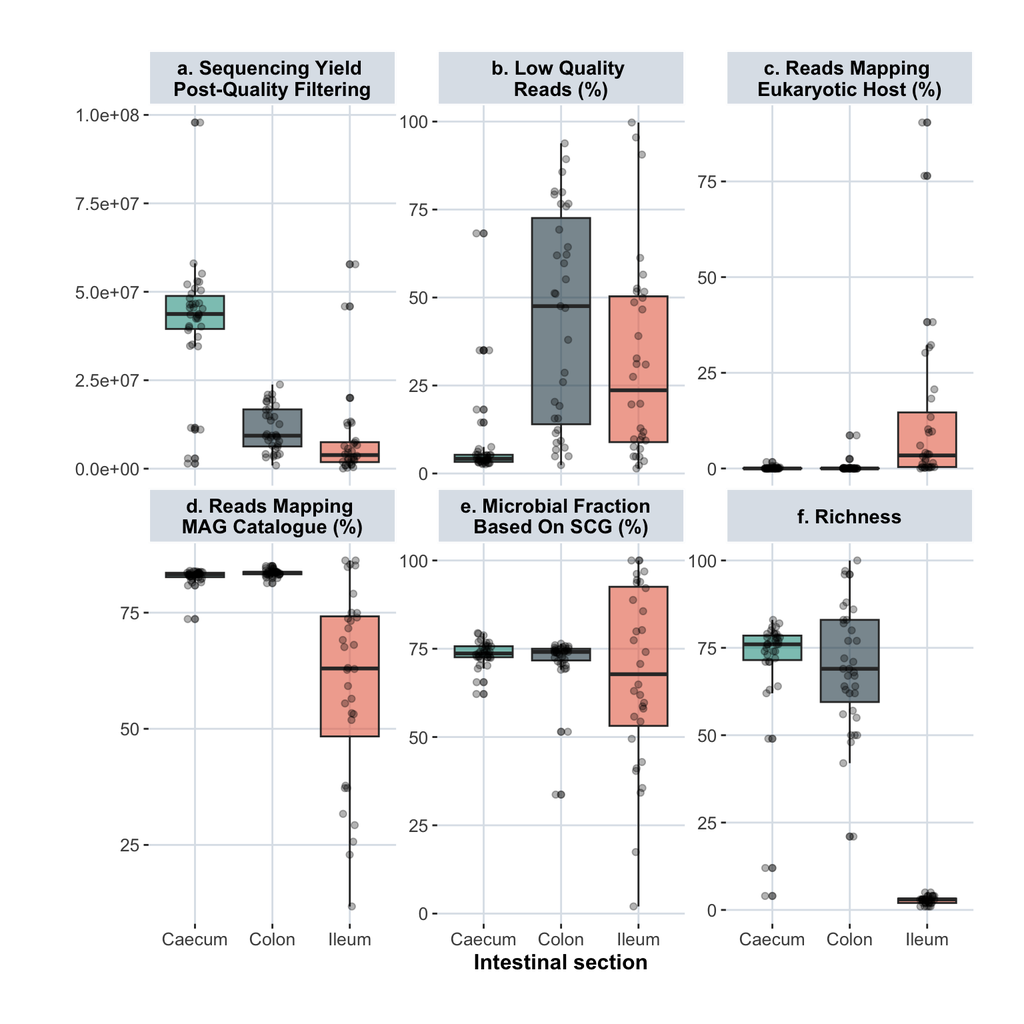

```r
ordered_metrics <- c(
  "total_after_filtering.total_reads",
  "lowquality_reads_pct",
  "host_pct",
  "mapmag_prokreads_pct",
  "read_fraction_singlem",
  "richness"
)

figs3_3_1 <- sn3_3_df %>%
  filter(!cycles %in% c("19")) %>%
  mutate(
    lowquality_reads_pct = lowquality_reads_pct * 100,
    host_pct = host_pct * 100,
    mapmag_prokreads_pct = mapmag_prokreads_pct * 100,
    read_fraction_singlem = read_fraction_singlem * 100
  ) %>%
  pivot_longer(
    cols = -c(names(mssm_sample_metadata), "cov_filtering"),
    names_to = "metric",
    values_to = "value"
  ) %>%
  filter(metric %in% ordered_metrics) %>%
  mutate(
    metric = factor(metric, levels = ordered_metrics),
    metric = fct_recode(metric,
      "a. Sequencing Yield \nPost-Quality Filtering" = "total_after_filtering.total_reads",
      "b. Low Quality \nReads (%)" = "lowquality_reads_pct",
      "c. Reads Mapping \nEukaryotic Host (%)" = "host_pct",
      "d. Reads Mapping \nMAG Catalogue (%)" = "mapmag_prokreads_pct",
      "e. Microbial Fraction  \nBased On SCG (%)" = "read_fraction_singlem",
      "f. Richness" = "richness"
    ),
    section = recode(section,
      "Caecum right" = "Caecum",
      "Colon" = "Colon"
    )
  ) %>%
  ggplot(aes(x = section, y = value, fill = section)) +
  geom_boxplot(alpha = 0.6) +
  facet_wrap(~metric, scales = "free_y", ncol = 3) +
  labs(
    fill = "",
    y = "",
    x = "Intestinal section"
  ) +
  # geom_violin(trim = TRUE, alpha = 0.7, position = position_dodge(0.8), na.rm = TRUE) +  # Violin plot
  geom_jitter(
    position = position_jitterdodge(jitter.width = 0.2, dodge.width = 0.8),
    size = 1.5, alpha = 0.3
  ) +
  scale_fill_manual(values = c("#2A9D8F", "#264653", "#E76F51")) +
  custom_ggplot_theme +
  theme(legend.position = "none")

figs3_3_1
```

Library-building performance, evaluated using sequencing and diversity metrics, was highest in the caecum, lower in the colon, and poorest in the ileum.

#### 3.3.2.2 Statistical Comparison Of Sequencing Performance

##### a. Reads Retained Post Quality Filtering

```r
# Counts (integers ≥0): poisson, quasipoisson (accounts overdispersion)
sn3_3_a <- fit_and_analyze_model(
  model = "glm",
  distribution = "quasipoisson",
  response_var = "total_after_filtering.total_reads",
  explanatory_var = "collection_attempts + section",
  data = sn3_3_df %>% filter(!cycles %in% c("19"))
)

# cat("Anova", "\n")
knitr::kable(
  sn3_3_a$anova,
  digits = 3,
  booktabs = TRUE,
  align = "lccc"
)
```

| term | sumsq | df | statistic | p.value |
| --- | --- | --- | --- | --- |
| collection_attempts | 40627645 | 3 | 1.489 | 0.222 |
| section | 1104588118 | 2 | 60.735 | 0.000 |
| Residuals | 872972895 | 96 | NA | NA |

```r
# # cat("Predicted values from model", "\n")
knitr::kable(
  sn3_3_a$model_fit %>% ggpredict(., terms = c("section")),
  digits = 3,
  booktabs = TRUE,
  align = "lccc"
)
```

| x | predicted | std.error | conf.low | conf.high | group |
| --- | --- | --- | --- | --- | --- |
| Caecum right | 41540698 | 0.096 | 34337045 | 50255624 | 1 |
| Ileum | 7807323 | 0.205 | 5197343 | 11727973 | 1 |
| Colon | 9882423 | 0.172 | 7020420 | 13911175 | 1 |

##### b. Low Quality Reads (%)

```r
# Proportions (0–1 continuous): quasibinomial GLM (accounts overdispersion)
sn3_3_b <- fit_and_analyze_model(
  model = "glm",
  distribution = "quasibinomial",
  response_var = "lowquality_reads_pct",
  explanatory_var = "collection_attempts + section",
  data = sn3_3_df %>% filter(!cycles %in% c("19"))
)

# cat("Anova", "\n")
knitr::kable(
  sn3_3_b$anova,
  digits = 3,
  booktabs = TRUE,
  align = "lccc"
)
```

| term | sumsq | df | statistic | p.value |
| --- | --- | --- | --- | --- |
| collection_attempts | 3.704 | 3 | 4.180 | 0.008 |
| section | 15.273 | 2 | 25.851 | 0.000 |
| Residuals | 28.359 | 96 | NA | NA |

```r
# cat("Predicted values from model", "\n")
knitr::kable(
  sn3_3_b$model_fit %>% ggpredict(., terms = c("section")),
  digits = 3,
  booktabs = TRUE,
  align = "lccc"
)
```

| x | predicted | std.error | conf.low | conf.high | group |
| --- | --- | --- | --- | --- | --- |
| Caecum right | 0.074 | 0.379 | 0.036 | 0.145 | 1 |
| Ileum | 0.353 | 0.257 | 0.247 | 0.476 | 1 |
| Colon | 0.511 | 0.223 | 0.402 | 0.619 | 1 |

##### c. Reads Mapping Eukaryotic Host (%)

```r
# Proportions (0–1 continuous): quasibinomial GLM (accounts overdispersion)
sn3_3_c <- fit_and_analyze_model(
  model = "glm",
  distribution = "quasibinomial",
  response_var = "host_pct",
  explanatory_var = "collection_attempts + section",
  data = sn3_3_df %>% filter(!cycles %in% c("19"))
)

# cat("Anova", "\n")
knitr::kable(
  sn3_3_c$anova,
  digits = 3,
  booktabs = TRUE,
  align = "lccc"
)
```

| term | sumsq | df | statistic | p.value |
| --- | --- | --- | --- | --- |
| collection_attempts | 2.154 | 3 | 5.019 | 0.003 |
| section | 10.395 | 2 | 36.325 | 0.000 |
| Residuals | 13.735 | 96 | NA | NA |

```r
# cat("Predicted values from model", "\n")
knitr::kable(
  sn3_3_c$model_fit %>% ggpredict(., terms = c("section")),
  digits = 3,
  booktabs = TRUE,
  align = "lccc"
)
```

| x | predicted | std.error | conf.low | conf.high | group |
| --- | --- | --- | --- | --- | --- |
| Caecum right | 0.001 | 2.071 | 0.000 | 0.053 | 1 |
| Ileum | 0.146 | 0.283 | 0.089 | 0.231 | 1 |
| Colon | 0.002 | 1.170 | 0.000 | 0.017 | 1 |

##### d. Reads Mapping MAG Catalogue (%)

```r
# Proportions (0–1 continuous): quasibinomial GLM (accounts overdispersion)
sn3_3_d <- fit_and_analyze_model(
  model = "glm",
  distribution = "quasibinomial",
  response_var = "mapmag_prokreads_pct",
  explanatory_var = "collection_attempts + section",
  data = sn3_3_df %>% filter(!cycles %in% c("19"))
)

# cat("Anova", "\n")
knitr::kable(
  sn3_3_d$anova,
  digits = 3,
  booktabs = TRUE,
  align = "lccc"
)
```

| term | sumsq | df | statistic | p.value |
| --- | --- | --- | --- | --- |
| collection_attempts | 0.211 | 3 | 1.246 | 0.297 |
| section | 5.675 | 2 | 50.322 | 0.000 |
| Residuals | 5.414 | 96 | NA | NA |

```r
# cat("Predicted values from model", "\n")
knitr::kable(
  sn3_3_d$model_fit %>% ggpredict(., terms = c("section")),
  digits = 3,
  booktabs = TRUE,
  align = "lccc"
)
```

| x | predicted | std.error | conf.low | conf.high | group |
| --- | --- | --- | --- | --- | --- |
| Caecum right | 0.841 | 0.120 | 0.806 | 0.870 | 1 |
| Ileum | 0.615 | 0.109 | 0.563 | 0.665 | 1 |
| Colon | 0.840 | 0.124 | 0.804 | 0.870 | 1 |

##### e. Microbial Fraction Based On Single-Copy Gene Abundance (%)

```r
# Proportions (0–1 continuous): quasibinomial GLM (accounts overdispersion)
sn3_3_e <- fit_and_analyze_model(
  model = "glm",
  distribution = "quasibinomial",
  response_var = "read_fraction_singlem",
  explanatory_var = "collection_attempts + section",
  data = sn3_3_df %>% filter(!cycles %in% c("19"))
)

# cat("Anova", "\n")
knitr::kable(
  sn3_3_e$anova,
  digits = 3,
  booktabs = TRUE,
  align = "lccc"
)
```

| term | sumsq | df | statistic | p.value |
| --- | --- | --- | --- | --- |
| collection_attempts | 0.297 | 3 | 0.914 | 0.437 |
| section | 0.394 | 2 | 1.820 | 0.167 |
| Residuals | 10.396 | 96 | NA | NA |

```r
# cat("Predicted values from model", "\n")
knitr::kable(
  sn3_3_e$model_fit %>% ggpredict(., terms = c("section")),
  digits = 3,
  booktabs = TRUE,
  align = "lccc"
)
```

| x | predicted | std.error | conf.low | conf.high | group |
| --- | --- | --- | --- | --- | --- |
| Caecum right | 0.748 | 0.143 | 0.690 | 0.797 | 1 |
| Ileum | 0.677 | 0.152 | 0.608 | 0.739 | 1 |
| Colon | 0.723 | 0.144 | 0.662 | 0.777 | 1 |

```r
cat("Correlation", "\n")
```

```
Correlation
```

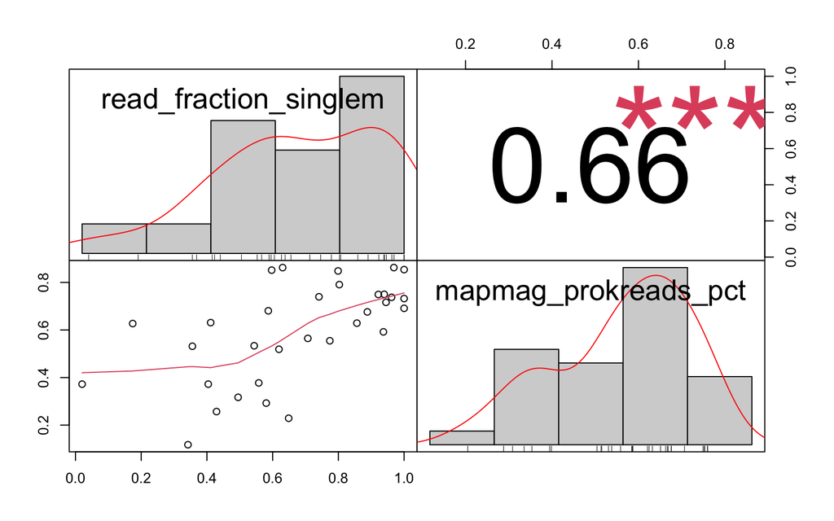

```r
chart.Correlation(sn3_3_df %>%
  filter(section %in% c("Ileum")) %>%
  select(
    "read_fraction_singlem",
    "mapmag_prokreads_pct"
  ), method = "spearman")
```

Single-copy gene analysis showed a moderate correlation with the proportion of reads mapping to the reference post-filtering.

#### 3.3.2.3 Colon: 19 Versus 15 Cycles

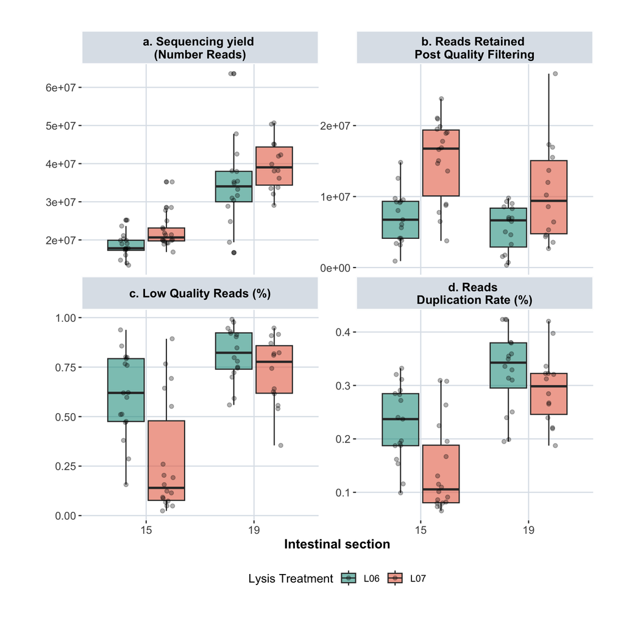

```r
ordered_metrics <- c(
  "total_before_filtering.total_reads",
  "total_after_filtering.total_reads",
  "lowquality_reads_pct",
  "percent_duplication.rate"
)

sn_3_3_15vs19 <- sn3_3_df %>%
  filter(section %in% c("Colon")) %>%
  pivot_longer(
    cols = -c(names(mssm_sample_metadata), "cov_filtering"),
    names_to = "metric",
    values_to = "value"
  ) %>%
  filter(metric %in% ordered_metrics) %>%
  mutate(
    metric = factor(metric, levels = ordered_metrics),
    metric = fct_recode(metric,
      "a. Sequencing yield \n(Number Reads)" = "total_before_filtering.total_reads",
      "b. Reads Retained \nPost Quality Filtering" = "total_after_filtering.total_reads",
      "c. Low Quality Reads (%)" = "lowquality_reads_pct",
      "d. Reads \nDuplication Rate (%)" = "percent_duplication.rate"
    )
  ) %>%
  ggplot(aes(x = cycles, y = value, fill = buffer)) +
  geom_boxplot(alpha = 0.6) +
  facet_wrap(~metric, scales = "free_y", ncol = 2) +
  labs(
    fill = "Lysis Treatment",
    y = "",
    x = "Intestinal section"
  ) +
  geom_jitter(
    position = position_jitterdodge(jitter.width = 0.2, dodge.width = 0.8),
    size = 1.5, alpha = 0.3
  ) +
  scale_fill_manual(values = c("#2A9D8F", "#E76F51")) +
  custom_ggplot_theme +
  theme(legend.position = "bottom")
sn_3_3_15vs19
```

##### a. Sequencing Yield (Number Reads)

```r
# Counts (integers ≥0): poisson, quasipoisson (accounts overdispersion)
readsbf_cyclecomp <- fit_and_analyze_model(
  model = "glm",
  distribution = "quasipoisson",
  response_var = "total_before_filtering.total_reads",
  explanatory_var = "collection_attempts + cycles",
  data = sn3_3_df %>% filter(section %in% c("Colon"))
)

# cat("Anova", "\n")
knitr::kable(
  readsbf_cyclecomp$anova,
  digits = 3,
  booktabs = TRUE,
  align = "lccc"
)
```

| term | sumsq | df | statistic | p.value |
| --- | --- | --- | --- | --- |
| collection_attempts | 492386.6 | 2 | 0.150 | 0.861 |
| cycles | 154708029.9 | 1 | 94.323 | 0.000 |
| Residuals | 100052058.2 | 61 | NA | NA |

```r
# cat("Predicted values from model", "\n")
knitr::kable(
  readsbf_cyclecomp$model_fit %>% ggpredict(., terms = c("cycles")),
  digits = 3,
  booktabs = TRUE,
  align = "lccc"
)
```

| x | predicted | std.error | conf.low | conf.high | group |
| --- | --- | --- | --- | --- | --- |
| 15 | 20601289 | 0.055 | 18470098 | 22978390 | 1 |
| 19 | 37405618 | 0.048 | 34008351 | 41142255 | 1 |

##### b. Reads Retained Post Quality Filtering

```r
# Counts (integers ≥0): poisson, quasipoisson (accounts overdispersion)
readshq_cyclecomp <- fit_and_analyze_model(
  model = "glm",
  distribution = "quasipoisson",
  response_var = "total_after_filtering.total_reads",
  explanatory_var = "collection_attempts + cycles",
  data = sn3_3_df %>% filter(section %in% c("Colon"))
)

# cat("Anova", "\n")
knitr::kable(
  readshq_cyclecomp$anova,
  digits = 3,
  booktabs = TRUE,
  align = "lccc"
)
```

| term | sumsq | df | statistic | p.value |
| --- | --- | --- | --- | --- |
| collection_attempts | 28529368 | 2 | 4.135 | 0.021 |
| cycles | 16953446 | 1 | 4.915 | 0.030 |
| Residuals | 210414932 | 61 | NA | NA |

```r
# cat("Predicted values from model", "\n")
knitr::kable(
  readshq_cyclecomp$model_fit %>% ggpredict(., terms = c("cycles")),
  digits = 3,
  booktabs = TRUE,
  align = "lccc"
)
```

| x | predicted | std.error | conf.low | conf.high | group |
| --- | --- | --- | --- | --- | --- |
| 15 | 9189837 | 0.123 | 7186626 | 11751426 | 1 |
| 19 | 6542893 | 0.147 | 4873356 | 8784389 | 1 |

##### c. Low Quality Reads (%)

```r
# Proportions (0–1 continuous): quasibinomial GLM (accounts overdispersion)
quality_cyclecomp <- fit_and_analyze_model(
  model = "glm",
  distribution = "quasibinomial",
  response_var = "lowquality_reads_pct",
  explanatory_var = "collection_attempts + cycles",
  data = sn3_3_df %>% filter(section %in% c("Colon"))
)

# cat("Anova", "\n")
knitr::kable(
  quality_cyclecomp$anova,
  digits = 3,
  booktabs = TRUE,
  align = "lccc"
)
```

| term | sumsq | df | statistic | p.value |
| --- | --- | --- | --- | --- |
| collection_attempts | 1.572 | 2 | 3.112 | 0.052 |
| cycles | 7.880 | 1 | 31.209 | 0.000 |
| Residuals | 15.403 | 61 | NA | NA |

```r
# cat("Predicted values from model", "\n")
knitr::kable(
  quality_cyclecomp$model_fit %>% ggpredict(., terms = c("cycles")),
  digits = 3,
  booktabs = TRUE,
  align = "lccc"
)
```

| x | predicted | std.error | conf.low | conf.high | group |
| --- | --- | --- | --- | --- | --- |
| 15 | 0.511 | 0.207 | 0.409 | 0.613 | 1 |
| 19 | 0.829 | 0.272 | 0.738 | 0.893 | 1 |

##### d. Reads Duplication Rate (%)

```r
# Proportions (0–1 continuous): quasibinomial GLM (accounts overdispersion)
duplication_cyclecomp <- fit_and_analyze_model(
  model = "glm",
  distribution = "quasibinomial",
  response_var = "percent_duplication.rate",
  explanatory_var = "collection_attempts + cycles",
  data = sn3_3_df %>% filter(section %in% c("Colon"))
)

# cat("Anova", "\n")
knitr::kable(
  duplication_cyclecomp$anova,
  digits = 3,
  booktabs = TRUE,
  align = "lccc"
)
```

| term | sumsq | df | statistic | p.value |
| --- | --- | --- | --- | --- |
| collection_attempts | 0.270 | 2 | 3.721 | 0.03 |
| cycles | 1.443 | 1 | 39.815 | 0.00 |
| Residuals | 2.211 | 61 | NA | NA |

```r
# cat("Predicted values from model", "\n")
knitr::kable(
  duplication_cyclecomp$model_fit %>% ggpredict(., terms = c("cycles")),
  digits = 3,
  booktabs = TRUE,
  align = "lccc"
)
```

| x | predicted | std.error | conf.low | conf.high | group |
| --- | --- | --- | --- | --- | --- |
| 15 | 0.203 | 0.094 | 0.174 | 0.236 | 1 |
| 19 | 0.342 | 0.091 | 0.302 | 0.384 | 1 |

Efforts to compensate for low biomass in the colon by increasing PCR cycles did not improve the quality of colon results.

#### 3.3.2.4 Community Composition of Caecum & Colon (Fig. S3.3.2)

**Note:** The pivot_phylo() function needs to be loaded.

```r
sn3_3_physeq_lg <- pivot_phylo(
  phyloseq_obj = subset_samples(
    physeq_all,
    batch %in% c("MSEB0006", "MSEB0010") &
      section %in% c("Caecum right", "Colon") &
      !cycles %in% c(19) &
      type == "positive"
  ),
  glom = TRUE,
  tax_transform = TRUE,
  taxon_level = "order",
  tr_method = "compositional"
)
```

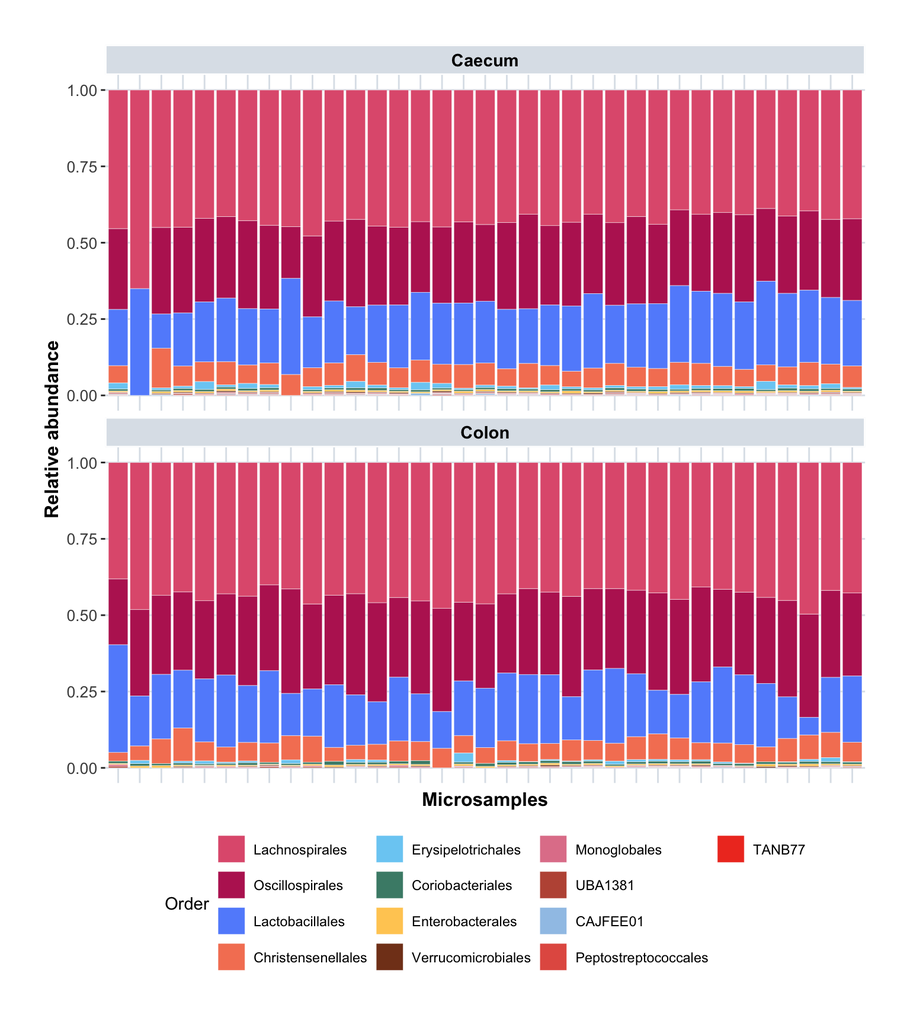

```r
figs3_3_2 <- sn3_3_physeq_lg %>%
  mutate(section = ifelse(section == "Caecum right", "Caecum", section)) %>%
  ggplot(
    aes(x = microsample, y = abundance, fill = order)
  ) +
  geom_bar(stat = "identity", colour = "white", linewidth = 0.1) +
  scale_fill_manual(values = order_colors, drop = FALSE) +
  labs(
    x = "Microsamples",
    y = "Relative abundance",
    fill = "Order"
  ) +
  facet_wrap(~section, scales = "free", ncol = 1) +
  guides(fill = guide_legend(ncol = 4)) +
  custom_ggplot_theme +
  theme(axis.text.x = element_blank(), axis.ticks.x = element_blank()) +
  theme(legend.position = "bottom")
figs3_3_2
```

##### Differential Abundance (Aldex2)

```r
sn3_3_physeq <- subset_samples(
  physeq_all,
  section %in% c("Caecum right", "Colon") &
    !cycles %in% c(19) &
    animal %in% c("G121e") &
    type == "positive"
)
sn3_3_physeq <- prune_taxa(taxa_sums(sn3_3_physeq) > 0, sn3_3_physeq)
sn3_3_aldex_G121e_counts <- data.frame(otu_table(sn3_3_physeq))
sn3_3_aldex_G121e_pseudo_counts <- round(sn3_3_aldex_G121e_counts * 1e6)
sn3_3_aldex_G121e_conditions <- data.frame(sample_data(sn3_3_physeq)) %>% pull(section)
# Perform the ALDEx2 differential abundance test
# Use 't' test for two groups; 'glm' for multi-class or covariates
sn3_3_aldex_G121e_results <- aldex(sn3_3_aldex_G121e_pseudo_counts,
  sn3_3_aldex_G121e_conditions,
  test = "t", # or "wilcox"
  effect = TRUE, # include effect sizes
  denom = "all", # normalization denominator
  mc.samples = 256, # number of Monte Carlo instances
  verbose = TRUE
)
```

```
|------------(25%)----------(50%)----------(75%)----------|
```

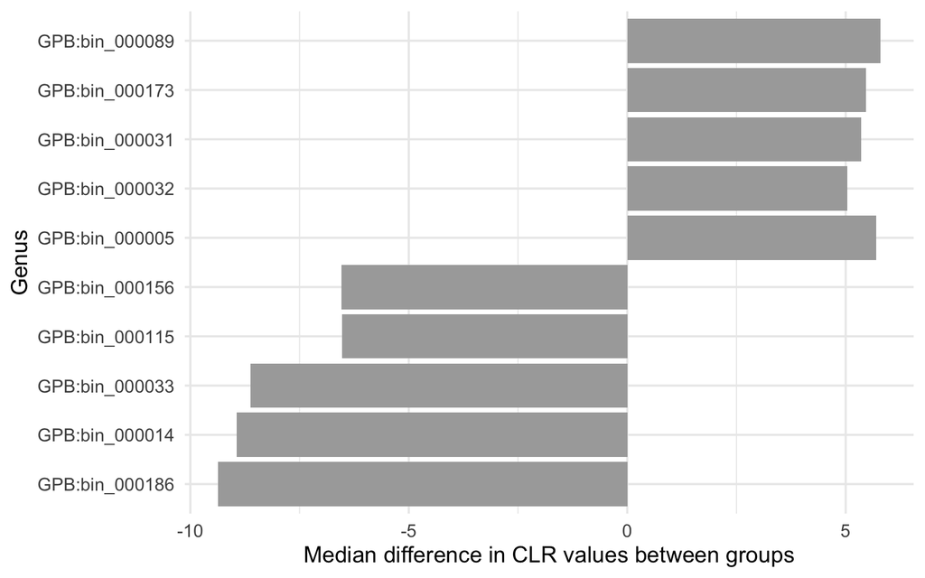

```r
# - we.ep: expected p-value from Welch's t-test
# - wi.ep: expected p-value from Wilcoxon test
# - we.eBH: BH-adjusted p-value (q-value)
# - effect: effect size (difference in clr means / variability)
# Filter
sn3_3_aldex_G121e_sig <- sn3_3_aldex_G121e_results[sn3_3_aldex_G121e_results$we.eBH < 0.05, ]
sn3_3_aldex_G121e_effect <- sn3_3_aldex_G121e_sig[abs(sn3_3_aldex_G121e_sig$effect) > 0.5, ]

sn3_3_aldex <-
  sn3_3_aldex_G121e_effect %>%
  rownames_to_column("genome") %>%
  left_join(data.frame(tax_table(sn3_3_physeq)) %>% rownames_to_column("genome"), by = "genome")

# Create horizontal barplot
sn3_3_aldex %>%
  ggplot(., aes(x = reorder(genome, effect), y = diff.btw, fill = abs(effect) > 1)) +
  geom_bar(stat = "identity", show.legend = FALSE) +
  coord_flip() +
  labs(
    x = "Genus",
    y = "Median difference in CLR values between groups"
  ) +
  scale_fill_manual(values = c("TRUE" = "#e35d51", "FALSE" = "darkgrey")) +
  theme_minimal(base_size = 14)
```

#### 3.3.2.5 Confocal Microscopy Of DAPI-stained Microsections (Fig. S3.3.3a)

```r
sn3_3_dapi_df <- dapi_df %>%
  group_by(Animal, Sequence, Age, Section) %>%
  summarise(
    n = n(),
    Distance_from_one_side_mn = mean(Distance_from_one_side, na.rm = TRUE),
    Distance_from_one_side_sd = ifelse(n > 1, sd(Distance_from_one_side), NA_real_),
    mean = mean(Bacterial_count),
    median = median(Bacterial_count),
    sd_na = ifelse(n > 1, sd(Bacterial_count), NA_real_), # If only 1 obs, return NA
    sd = ifelse(n() > 1, sd(Bacterial_count, na.rm = TRUE), 0), # Avoid NA SD
    sem = ifelse(n > 1, sd / sqrt(n), 0), # Set SEM to 0 if only 1 observation
    q1 = quantile(Bacterial_count, 0.25), # First quartile
    q3 = quantile(Bacterial_count, 0.75), # Third quartile
    .groups = "drop"
  )
summary <- dapi_df %>%
  group_by(Age, Section) %>%
  summarise(
    n = n(),
    mean = mean(Bacterial_count),
    median = median(Bacterial_count),
    sd_na = ifelse(n > 1, sd(Bacterial_count), NA_real_), # If only 1 obs, return NA
    sd = ifelse(n() > 1, sd(Bacterial_count, na.rm = TRUE), 0), # Avoid NA SD
    q1 = quantile(Bacterial_count, 0.25), # First quartile
    q3 = quantile(Bacterial_count, 0.75), # Third quartile
    .groups = "drop"
  )
```

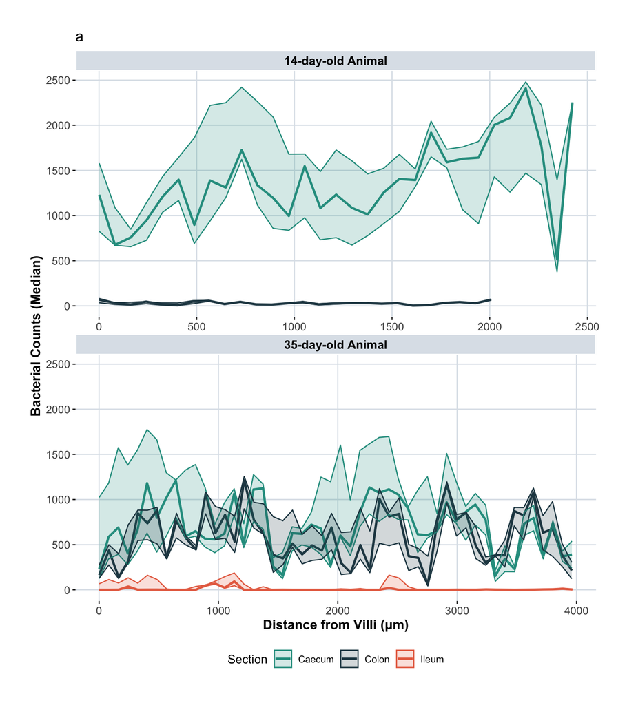

```r
figs3_3_3a <- ggplot(sn3_3_dapi_df, aes(x = Distance_from_one_side_mn, y = median, color = Section)) +
  geom_line(linewidth = 1) + # Mean line
  geom_ribbon(aes(ymin = q1, ymax = q3, fill = Section),
    alpha = 0.2
  ) + # SEM shading
  labs(
    title = "a",
    x = "Distance from Villi (μm)",
    y = "Bacterial Counts (Median)"
  ) +
  facet_wrap(~Age, nrow = 2, scale = "free_x") +
  scale_fill_manual(values = c("#2A9D8F", "#264653", "#E76F51"), drop = FALSE) +
  scale_color_manual(values = c("#2A9D8F", "#264653", "#E76F51"), drop = FALSE) +
  custom_ggplot_theme +
  theme(legend.position = "bottom")
figs3_3_3a
```

Quantification of bacterial cells within a 5,000 μm² area using QuPath provides visual confirmation that differences in bacterial density across intestinal regions (caecum, colon, and ileum) were the primary factor influencing MSSM performance.

## 3.4 Design Considerations: Controls (Suppl. Note 3.4)

### 3.4.1 Visual Comparison Of Sequencing Performance (Fig. S3.4.1)

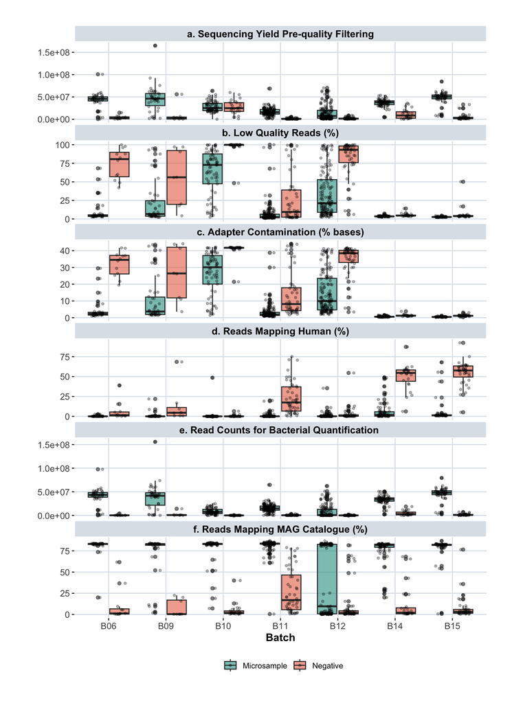

```r
ordered_metrics <- c(
  "total_before_filtering.total_reads",
  "lowquality_reads_pct",
  "adapter_contamination_pct",
  "human_pct",
  "raw_total_sequences_mag",
  "mapmag_prokreads_pct"
)

figs3_4_1 <- macroquant_metrics_filt_30 %>%
  filter(!section %in% c("Ileum")) %>%
  mutate(
    batch = gsub("MSEB00", "B", batch),
    lowquality_reads_pct = lowquality_reads_pct * 100,
    adapter_contamination_pct = adapter_contamination_pct * 100,
    human_pct = human_pct * 100,
    mapmag_prokreads_pct = mapmag_prokreads_pct * 100
  ) %>%
  pivot_longer(
    cols = -c(names(mssm_sample_metadata), "cov_filtering"),
    names_to = "metric",
    values_to = "value"
  ) %>%
  filter(metric %in% ordered_metrics) %>%
  mutate(
    metric = factor(metric, levels = ordered_metrics),
    metric = fct_recode(metric,
      "a. Sequencing Yield Pre-quality Filtering" = "total_before_filtering.total_reads",
      "b. Low Quality Reads (%)" = "lowquality_reads_pct",
      "c. Adapter Contamination (% bases)" = "adapter_contamination_pct",
      "d. Reads Mapping Human (%)" = "human_pct",
      "e. Read Counts for Bacterial Quantification " = "raw_total_sequences_mag",
      "f. Reads Mapping MAG Catalogue (%)" = "mapmag_prokreads_pct"
    ),
    type = recode(type,
      "positive" = "Microsample",
      "negative" = "Negative"
    )
  ) %>%
  ggplot(aes(x = batch, y = value, fill = type)) +
  geom_boxplot(alpha = 0.6) +
  facet_wrap(~metric, scales = "free_y", ncol = 1) +
  labs(
    fill = "",
    y = "",
    x = "Batch"
  ) +
  # geom_violin(trim = TRUE, alpha = 0.7, position = position_dodge(0.8), na.rm = TRUE) +  # Violin plot
  geom_jitter(
    position = position_jitterdodge(jitter.width = 0.2, dodge.width = 0.8),
    size = 1, alpha = 0.3
  ) +
  scale_fill_manual(values = c("#2A9D8F", "#E76F51")) +
  custom_ggplot_theme +
  theme(legend.position = "bottom")

figs3_4_1
```

Although controls yielded sequencing data, they consistently exhibited poorer quality metrics.

### 3.4.2 Centered Log-Ratio (CLR) Transformation And Principal Component Analysis (PCA)

**Note:** The perform_pca() function needs to be loaded.

#### 3.4.2.1 FigS3_4_2

```r
neg_vs_pos_wide <- macroquant_genome_counts_tidy %>%
  filter( batch == "MSEB0006" | batch == "MSEB0009" | batch == "MSEB0011" | batch == "MSEB0014" | batch == "MSEB0015" | batch == "MSEB0010" | batch == "MSEB0012") %>% #
  filter(section != "Ileum") %>%
  filter(type != "ControlHuman") %>%
  # arrange samples: first negatives, then positives (for ALDEx2).
  arrange(type) %>%
  select(genome, microsample, count) %>%
  pivot_wider(
    names_from = genome,
    values_from = count,
    values_fill = 0
  ) %>%
  select(where(~ any(. != 0))) %>%
  mutate(across(-microsample, ~ . / rowSums(across(where(is.numeric))) * 100 )) %>%
  column_to_rownames(var = "microsample")

# Remove taxa in few samples, and samples with few taxa
neg_vs_pos_wide <- remove_samples_or_taxa(df = neg_vs_pos_wide,
                                     min_samples_per_taxon = 50,
                                     min_taxa_per_sample = 25)
```

```
Initial df: Rows (samples): 764 , Columns (taxa): 223
Removed: Rows (samples): 76 , Columns (taxa): 0
Resulting df: Rows (samples): 688 , Columns (taxa): 223
```

```r
# Remove taxa with less than 0.1% rel. abun. in all samples
neg_vs_pos_wide <- neg_vs_pos_wide %>% select(where(~ any(. >= 0.1)))

neg_pos_PCA <- perform_pca(neg_vs_pos_wide, z_delete = TRUE)
```

```
[1] "Zeros found"
```

```
No. adjusted imputations:  14226
Rows (samples) removed after zero replacement: 36
Columns (taxa) removed after zero replacement: 1
```

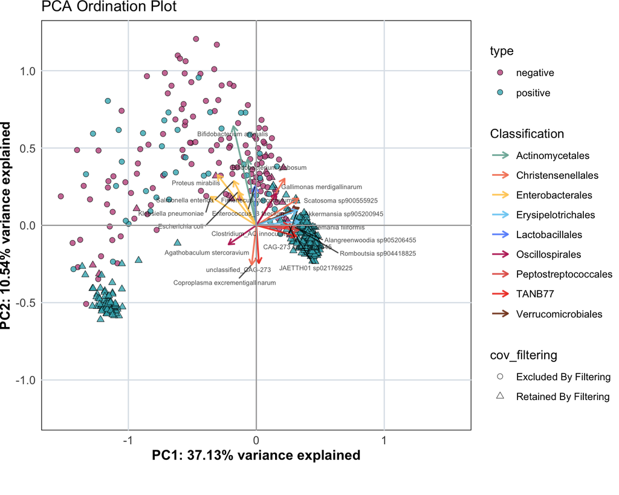

```r
figs3_4_2 <- plot_pca(neg_pos_PCA$pca_result,
  samples_color_metadata = "type",
  samples_shape_metadata = "cov_filtering",
  samples_color_value = c("#c1558b", "#3cb2bd"),
  loadings_color_metadata = "order",
  loadings_color_value = order_colors,
  loadings_taxon_level = "species",
  sample_metadata = macroquant_metrics_filt_30,
  genome_metadata = macromag_genomemetadata,
  order_colors,
  custom_ggplot_theme,
  loadings_number = 20
) +
  theme(plot.margin = unit(c(0, 0, 1, 0), "cm"))

figs3_4_2
```

#### 3.4.2.2 Coverage Cutoff Filtering (Fig. S3.4.3)

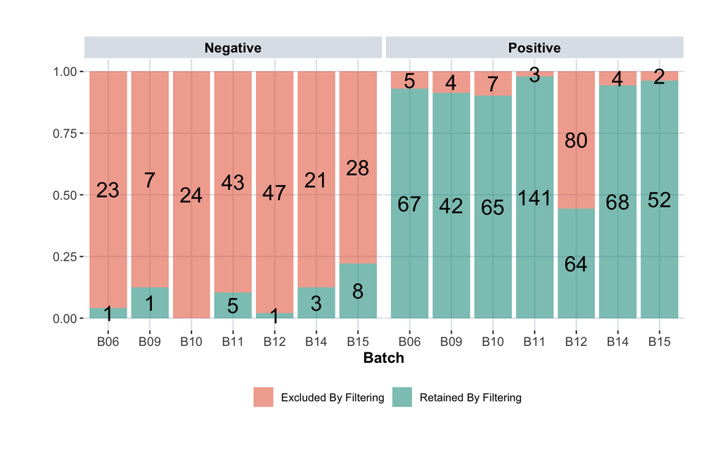

```r
figs3_4_3 <- macroquant_metrics_filt_30 %>%
  mutate(
    batch = gsub("MSEB00", "B", batch),
    type = recode(type,
      "positive" = "Positive",
      "negative" = "Negative"
    )
  ) %>%
  # group_by(type, cov_filtering) %>%
  group_by(batch, type, cov_filtering) %>%
  summarise(n_samples = n()) %>%
  ggplot(aes(fill = cov_filtering, x = batch, y = n_samples)) +
  geom_bar(position = "fill", stat = "identity", alpha = 0.6) + # Stacked 100% bar
  geom_text(aes(label = n_samples),
    position = position_fill(vjust = 0.5),
    color = "black", size = 6
  ) +
  facet_wrap(~type) +
  scale_fill_manual(values = c("#E76F51", "#2A9D8F")) +
  labs(
    fill = "",
    y = "",
    x = "Batch"
  ) +
  custom_ggplot_theme +
  theme(legend.position = "bottom")
figs3_4_3
```

```r
macroquant_metrics_filt_30 %>%
  filter( batch == "MSEB0006" | batch == "MSEB0009" | batch == "MSEB0011" | batch == "MSEB0014" | batch == "MSEB0015" | batch == "MSEB0010" | batch == "MSEB0012") %>%
  select(microsample, type, cov_filtering) %>%
  group_by(type) %>%
  count(cov_filtering) %>%
  mutate(percent = 100 * n / sum(n)) %>%
  knitr::kable()
```

| type | cov_filtering | n | percent |
| --- | --- | --- | --- |
| negative | Excluded By Filtering | 193 | 91.037736 |
| negative | Retained By Filtering | 19 | 8.962264 |
| positive | Excluded By Filtering | 105 | 17.384106 |
| positive | Retained By Filtering | 499 | 82.615894 |

#### 3.4.2.3 Composition

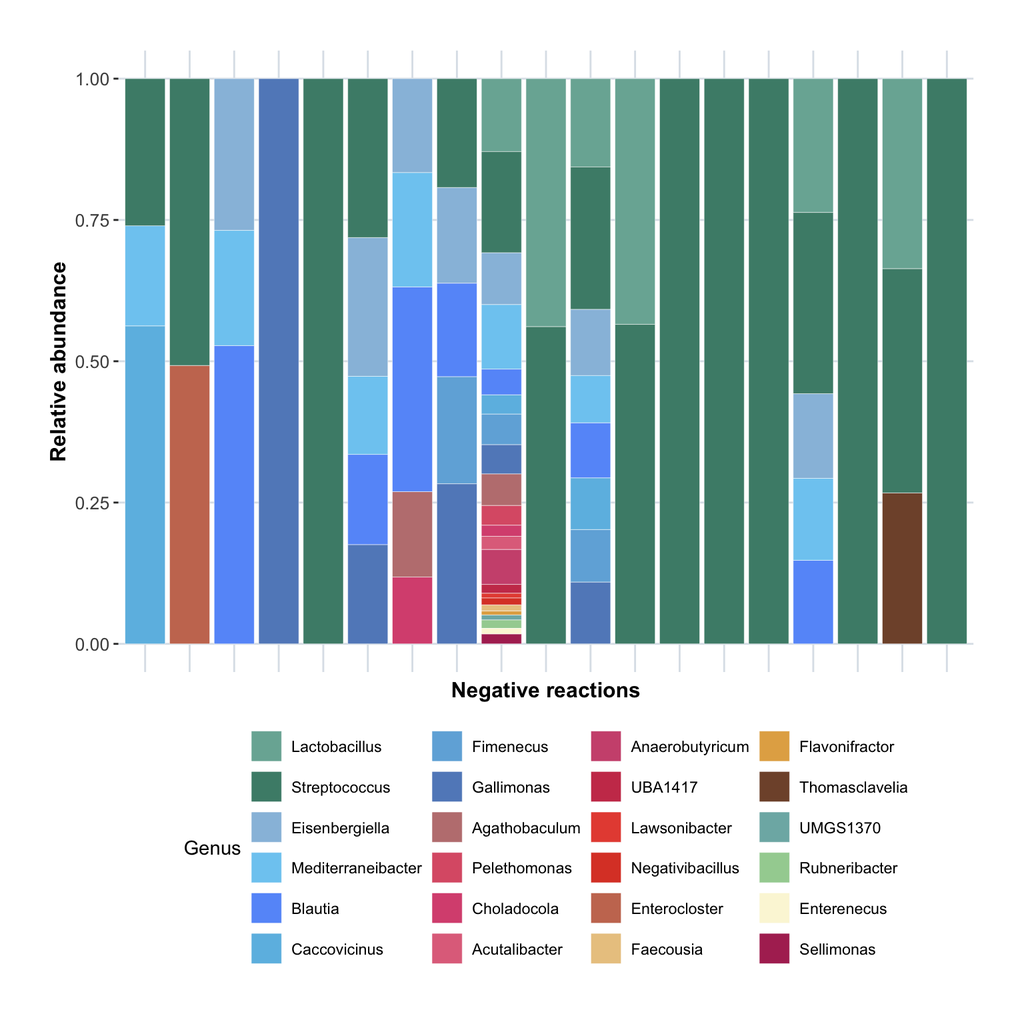

```r
sn3_4_physeq_lg <- pivot_phylo(
  phyloseq_obj = physeq_all,
  glom = TRUE,
  tax_transform = TRUE,
  taxon_level = "genus",
  tr_method = "compositional"
)

figs3_4_5 <- sn3_4_physeq_lg %>%
  filter(type %in% c("negative")) %>%
  ggplot(
    aes(x = microsample, y = abundance, fill = genus)
  ) +
  geom_bar(stat = "identity", colour = "white", linewidth = 0.1) +
  # scale_fill_manual(values = order_colors, drop = FALSE) +
  labs(
    x = "Negative reactions",
    y = "Relative abundance",
    fill = "Genus"
  ) +
  # facet_wrap(~batch, scale = "free") +
  guides(fill = guide_legend(ncol = 4)) +
  custom_ggplot_theme +
  theme(axis.text.x = element_blank(), axis.ticks.x = element_blank()) +
  theme(legend.position = "bottom") +
  scale_fill_manual(values = c(colorRampPalette(palette_color)(24)))
figs3_4_5
```

Elevated levels of Streptococcus were observed in negative reactions.

## 3.5 Design Considerations: Microsample Area

```r
custom_ggplot_theme_LMD_size <- custom_ggplot_theme +
  theme(
        legend.text = element_text(size = 7),
        legend.title = element_text(size = 7),
        axis.text = element_text(size = 5),
        axis.title = element_text(size = 7, face = "bold"),
        strip.text = element_text(size = 7, face = "bold", color = "black"),
        plot.title = element_text(size = 7, face = "bold", color = "black"),
        plot.margin = unit(c(0, 0, 0, 0), "cm"))

size_colors <- c("500" = '#ffdf9e', "1500" = '#ffc273', "2500" = '#e56969', "5000" = '#c1558b', "25000" = '#8a49a1',"50000" = '#4f5bd5')

# Make a-diversity df tidy for plotting
macroquant_metrics_filt_30_tidy <- macroquant_metrics_filt_30 %>%
  pivot_longer(
    cols = c(richness, neutral, phylogenetic),
    names_to = "metric",
    values_to = "value") %>%
  mutate(metric = factor(metric, levels = c("richness", "neutral", "phylogenetic")),
         size = factor(size, levels = c(500, 1500, 2500, 5000, 25000, 50000)))
```

### 3.5.1 Fig. 3b

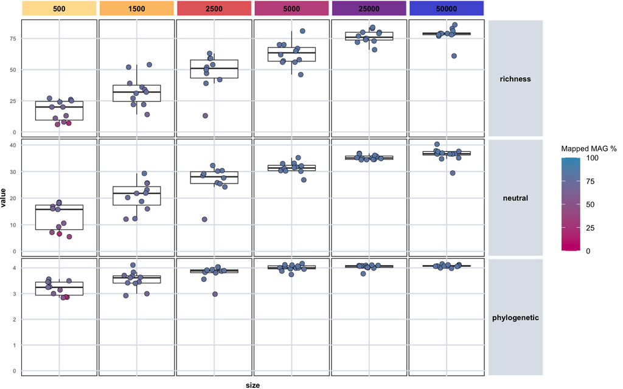

```r
# Plot a-diversity metrics for different microsample sizes
fig3b <- macroquant_metrics_filt_30_tidy %>%
  filter(batch == "MSEB0014") %>%
  filter(value > 1) %>% # to filter the samples with richness = 0, i.e. expShannon = 1
  filter(type == "positive") %>%
  ggplot(aes(x = size, y = value, fill = mapmag_filteredreads_pct*100)) +
    geom_boxplot(outlier.shape = NA, size = 0.3) +
    geom_jitter(shape = 21, color = "black",
                width = 0.2, alpha = 1,
                size = 2, stroke = 0.2) +
    scale_fill_gradient(low = "#c90076", high = "#3598bf",
                         name = "Mapped MAG %", limits = c(0, 100)) +
    facet_nested(metric ~ size, scales = "free", space = "fixed",
                 strip = strip_themed(
                  background_x = elem_list_rect(
                  fill = size_colors,
                  colour = "white",
                  size = 0.8))) +
    ylim(0, NA) +
    theme_minimal() +
    custom_ggplot_theme_LMD_size +
    theme(axis.text.x = element_blank())
fig3b
```

```r
# Mapped MAG median
macroquant_metrics_filt_30_tidy %>%
  filter(batch == "MSEB0014") %>%
  filter(metric == "richness") %>%
  filter(value > 1) %>%  # remove richness = 0 samples
  filter(type == "positive") %>%
  group_by(size) %>%
  summarise(
    median_pct = median(mapmag_filteredreads_pct * 100, na.rm = TRUE),
    IQR_pct    = IQR(mapmag_filteredreads_pct * 100, na.rm = TRUE),
    .groups = "drop"
  ) %>%
  knitr::kable()
```

| size | median_pct | IQR_pct |
| --- | --- | --- |
| 500 | 65.89115 | 16.3941394 |
| 1500 | 75.36138 | 4.3270866 |
| 2500 | 79.20876 | 1.6844339 |
| 5000 | 81.50319 | 1.5955203 |
| 25000 | 82.65133 | 0.4600388 |
| 50000 | 82.96293 | 0.4584162 |

### 3.5.2 Fig. 3c

```r
# Select data for PCA and make wide df
LMD_size_df_wide <- macroquant_genome_counts_filt_30_tidy %>%
  filter(batch == "MSEB0014") %>%
  filter(type == "positive") %>%
  select(genome, microsample, count,) %>% #  size
  pivot_wider(names_from = genome,values_from = count,values_fill = 0) %>%
  select(where(~ any(. != 0)) | where(is.character) | where(is.factor)) %>%
  mutate(across(-c(microsample), ~ . / rowSums(across(where(is.numeric))) * 100 )) %>%
  column_to_rownames(var = "microsample")

# 68 obs x 88 variables

# Remove samples with few taxa and taxa in few samples
LMD_size_df_wide <- remove_samples_or_taxa(df = LMD_size_df_wide,
                                           min_samples_per_taxon = 6,
                                           min_taxa_per_sample = 14)
```

```
Initial df: Rows (samples): 68 , Columns (taxa): 88
Removed: Rows (samples): 7 , Columns (taxa): 9
Resulting df: Rows (samples): 61 , Columns (taxa): 79
```

```r
# 61 obs x 79 variables
# Perform & plot PCA
LMD_size_pca <- perform_pca(LMD_size_df_wide, z_delete = TRUE)
```

```
[1] "Zeros found"
No. adjusted imputations:  129
Rows (samples) removed after zero replacement: 0
Columns (taxa) removed after zero replacement: 0
```

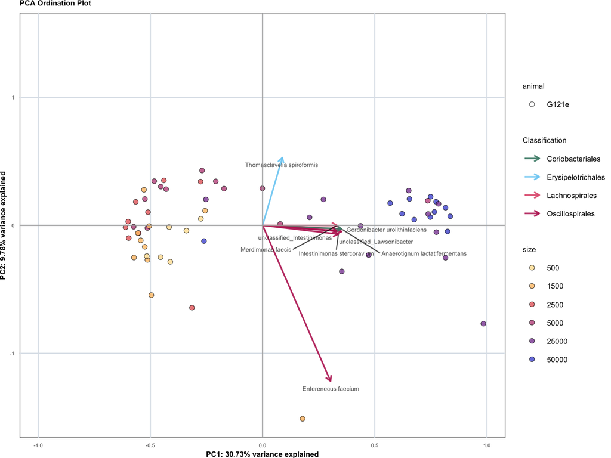

```r
fig3c <- plot_pca(LMD_size_pca$pca_result,
         samples_color_metadata = "size",
         samples_color_value = size_colors,
         samples_shape_metadata = "animal",
         loadings_color_metadata = "order",
         loadings_color_value = order_colors,
         loadings_taxon_level = "species",
         sample_metadata = macroquant_metrics_filt_30,
         genome_metadata = macromag_genomemetadata,
         order_colors= order_colors,
         custom_ggplot_theme = custom_ggplot_theme_LMD_size,
         loadings_number = 8)

fig3c
```

### 3.5.3 Fig. 3d

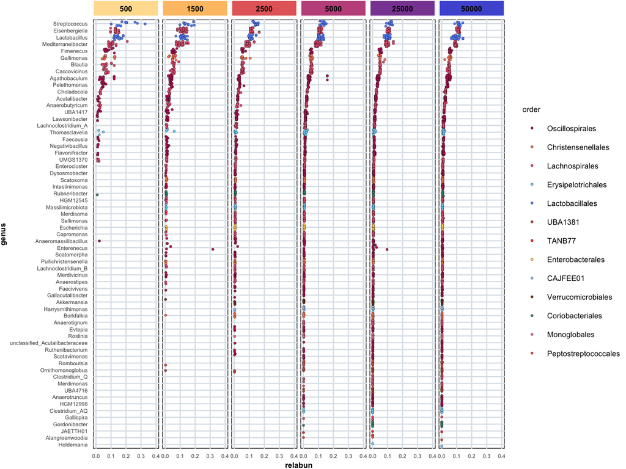

```r
# Relative abundance at genus level
LMD_size_rel_abun <- macroquant_genome_counts_filt_30_tidy %>%
  filter(batch == "MSEB0014") %>%
  filter(type == 'positive') %>%
  group_by(microsample, order, genus) %>%
  mutate(relabun = sum(count)) %>%
  ungroup()
# Plot relative abundance
LMD_size_taxa_sorted <- LMD_size_rel_abun %>%
  group_by(genus) %>%
  summarise(median = median(relabun, na.rm = T)) %>%
  arrange(-median)

# Reorder taxon_level based on the summary
fig3d <- LMD_size_rel_abun %>%
  mutate(genus = factor(genus, levels = rev(LMD_size_taxa_sorted %>% pull(genus))))  %>%
  ggplot(aes(x = relabun, y = genus, group = genus, fill = order)) +
      scale_fill_manual(values = order_colors) +
    geom_jitter(shape = 21, alpha = 1, size=1,
                color = "black", stroke = 0.1) +
    facet_nested(. ~  size,
                 scales = "free", space = "free", switch = "y",
                 strip = strip_themed(
                  background_x = elem_list_rect(
                  fill = size_colors,
                  colour = "white",
                  size = 0.8))) +
    theme_minimal() +
    custom_ggplot_theme_LMD_size +
    scale_x_continuous(limits = c(0, 0.4)) +
    theme(panel.spacing = unit(0.2, "lines"))

fig3d
```

## 3.6 Resource Optimisation and Throughput (Suppl. Note 3.5)

```r
sn3_5_df <- macroquant_metrics_filt_30 %>%
  filter(
    batch %in% c("MSEB0009", "MSEB0014", "MSEB0015"),
    type %in% c("positive"),
    size %in% c("5000"),
    !between(as.numeric(sub("M", "", microsample)), 300651, 300665)
  ) %>%
  mutate(
    protocol = ifelse(protocol %in% c("ULV2_Full"), "100%", "50%"),
    comparison = ifelse(batch %in% c("MSEB0009"), "Cost", "Throughput"),
    lib_method = ifelse(batch %in% c("MSEB0015"), "Automation (1 plate set-up)", "Manual"),
    comparison_grid = ifelse(comparison == "Cost", protocol, lib_method)
  ) %>%
  mutate(
    comparison = as.factor(comparison),
    comparison_grid = as.factor(comparison_grid)
  ) # %>% count(comparison, batch)
```

### 3.6.1 Summary Statistic

```r
sn3_5_df_t <- sn3_5_df %>%
  mutate(
    other = total_before_filtering.total_reads - ((total_before_filtering.total_reads - total_after_filtering.total_reads)
    + reads_mapped_chicken + reads_mapped_human + reads_mapped_pig + reads_mapped_mag + reads_unmapped_mag),
    low_quality_reads = total_before_filtering.total_reads - total_after_filtering.total_reads
  ) %>%
  select(
    microsample,
    comparison_grid,
    total_before_filtering.total_reads,
    low_quality_reads,
    reads_mapped_chicken,
    reads_mapped_human,
    reads_mapped_pig,
    reads_mapped_mag,
    reads_unmapped_mag, other
  ) %>%
  mutate(across(-c(microsample, comparison_grid, total_before_filtering.total_reads),
    ~ round((. / total_before_filtering.total_reads) * 100, 1),
    .names = "{.col}_pct"
  )) %>%
  select(microsample, comparison_grid, ends_with("_pct")) %>%
  group_by(comparison_grid) %>%
  summarise(
    low_quality_reads_md = median(low_quality_reads_pct),
    mapping_host_md = median(reads_mapped_chicken_pct),
    mapping_human_md = median(reads_mapped_human_pct),
    mapping_pig_md = median(reads_mapped_pig_pct),
    mapping_bacteria_md = median(reads_mapped_mag_pct),
    unmapped_bacteria_md = median(reads_unmapped_mag_pct),
    other_md = median(other_pct)
  ) %>%
  select(comparison_grid, ends_with("_md")) %>%
  t() %>%
  as.data.frame()

colnames(sn3_5_df_t) <- sn3_5_df_t[1, ]
sn3_5_df_t <- sn3_5_df_t[-1, ] # remove the first row

knitr::kable(
  sn3_5_df_t,
  digits = 3,
  booktabs = TRUE,
  align = "lccc"
)
```

|  | 100% | 50% | Automation (1 plate set-up) | Manual |
| --- | --- | --- | --- | --- |
| low_quality_reads_md | 11.95 | 3.30 | 2.60 | 3.55 |
| mapping_host_md | 0 | 0 | 0 | 0 |
| mapping_human_md | 0.00 | 0.00 | 1.35 | 1.20 |
| mapping_pig_md | 0 | 0 | 0 | 0 |
| mapping_bacteria_md | 72.40 | 80.45 | 78.85 | 78.65 |
| unmapped_bacteria_md | 15.2 | 16.2 | 17.0 | 16.6 |
| other_md | 0 | 0 | 0 | 0 |

#### 3.6.1.1 Visual Comparison Of Sequencing Performance (Fig. S3.5.1a)

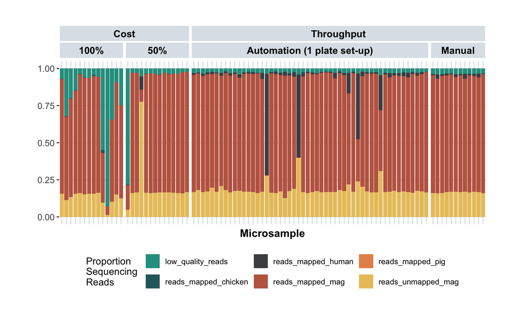

```r
ordered_metrics <- c(
  # "total_before_filtering.total_reads",
  "low_quality_reads",
  "reads_mapped_chicken",
  "reads_mapped_human",
  "reads_mapped_pig",
  "reads_mapped_mag",
  "reads_unmapped_mag",
  "reads_other"
)

figs3_5_1a <- sn3_5_df %>%
  mutate(
    other = total_before_filtering.total_reads - ((total_before_filtering.total_reads - total_after_filtering.total_reads)
    + reads_mapped_chicken + reads_mapped_human + reads_mapped_pig + reads_mapped_mag + reads_unmapped_mag),
    low_quality_reads = total_before_filtering.total_reads - total_after_filtering.total_reads
  ) %>%
  pivot_longer(
    cols = -c(names(mssm_sample_metadata), comparison, lib_method, comparison_grid, cov_filtering),
    names_to = "metric",
    values_to = "value"
  ) %>%
  filter(metric %in% ordered_metrics) %>%
  mutate(microsample = as.factor(microsample)) %>%
  ggplot(aes(x = microsample, y = value, fill = metric)) +
  geom_bar(position = "fill", stat = "identity") +
  scale_fill_manual(values = c(colorRampPalette(supplementary_color)(6))) +
  labs(x = "Microsample", y = "", fill = "Read type") +
  facet_nested(. ~ comparison + comparison_grid, scales = "free", space = "free", switch = "y") +
  theme(axis.text.x = element_text(angle = 90, hjust = 1)) +
  custom_ggplot_theme +
  theme(axis.text.x = element_blank(), axis.ticks.x = element_blank()) +
  theme(legend.position = "bottom") +
  guides(fill = guide_legend(title = "Proportion \nSequencing \nReads"))
figs3_5_1a
```

#### 3.6.1.2 Visual Comparison Of Library Preparation Efficiency (Fig. S3.5.1b)

```r
sn3_5_dreamprep_df_f <- sn3_5_dreamprep_df %>%
  mutate(plate = str_extract(sample, "^Plate \\d+")) %>%
  filter(
    !Range %in% c("35 bp to 100 bp"),
    concentration %in% c("0.1"),
    type %in% c("Positive")
  ) %>%
  mutate(
    # Range = droplevels(Range),
    plate = case_when(
      grepl("Plate 1", plate, ignore.case = TRUE) ~ "Single-Plate",
      grepl("Plate 2", plate, ignore.case = TRUE) ~ "Dual-Plate A",
      grepl("Plate 3", plate, ignore.case = TRUE) ~ "Dual-Plate B",
      TRUE ~ NA_character_
    ),
    plate = factor(plate, levels = c("Single-Plate", "Dual-Plate A", "Dual-Plate B")),
    concentration = paste0("DNA Input ", concentration, " ng/μL"),
    Range = case_when(
      grepl("100 bp to 200 bp", Range, ignore.case = TRUE) ~ "Non-specific Short Fragments",
      grepl("200 bp to 1000 bp", Range, ignore.case = TRUE) ~ "Library",
      TRUE ~ NA_character_
    )
  )
```

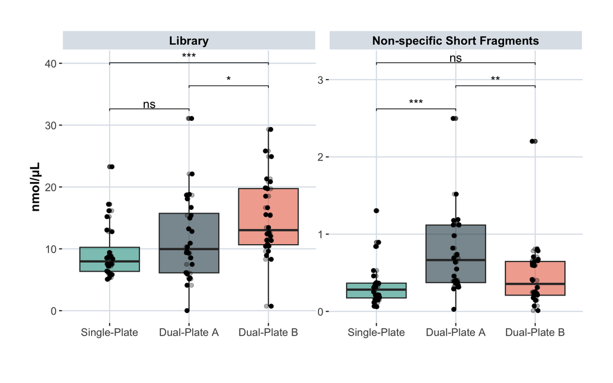

```r
comparisons <- list(c("Single-Plate", "Dual-Plate A"), c("Dual-Plate A", "Dual-Plate B"), c("Single-Plate", "Dual-Plate B"))
figs3_5_1b <- sn3_5_dreamprep_df_f %>%
  ggplot(aes(x = plate, y = nmole_L, fill = plate)) +
  geom_boxplot(position = position_dodge(width = 0.75), alpha = 0.6) +
  geom_point(position = position_jitterdodge(0.2)) +
  stat_compare_means(
    comparisons = comparisons,
    method = "wilcox.test",
    label = "p.signif",
    p.adjust.method = "BH",
    size = 4,
    vjust = 0.2,
    tip.length = 0.01
  ) +
  # scale_y_continuous(trans="log10") +
  facet_wrap(~Range, scales = "free") +
  labs(
    y = "nmol/μL",
    x = "",
  ) +
  geom_jitter(
    position = position_jitterdodge(jitter.width = 0.2, dodge.width = 0.8),
    size = 1.5, alpha = 0.3
  ) +
  scale_fill_manual(values = c("#2A9D8F", "#264653", "#E76F51")) +
  custom_ggplot_theme +
  theme(legend.position = "none")
figs3_5_1b
```